# BayesianModellingNotes1

Bayesian Modelling Lecture Notes 2027

Reading list

The notes are self-contained: reading outside course material isn’t essential.

But if you do want some further reading, the most relevant textbooks are:

- Gelman et al “Bayesian Data Analysis” (Good general reference)
- Plummer “The JAGS manual” (Useful for JAGS)  
  Available at https://sourceforge.net/projects/mcmc-jags/files/Manuals/4.x/jags_user_manual.pdf/download
- Robert “The Bayesian Choice” (Very thorough on decision theory, but quite technical)
- Stone “Bayes’ Rule With R” (Very accessible but only covers part of the course)

Some more general textbooks are:

- Kruschke “Doing Bayesian data analysis: a tutorial with R, JAGS, and Stan”
- McElreath “Statistical rethinking: a Bayesian course with examples in R and Stan”
- Murphy “Probabilistic machine learning: an introduction”

All these books are available in the university library or for free online.

Chapter 1 - Introduction

Bayes theorem is a basic theorem in probability.

Bayesian statistics uses Bayes theorem to solve statistical problems.

In particular, Bayesian inference fits models to data.

Chapter contents:

1. Simple motivating example to illustrate the basic idea
2. Review of Bayes theorem and introduction to general framework of Bayesian statistics
3. Opinion polling example, illustrating many concepts covered in later chapters
4. Philosophical interpretations of probability, and their relevance to Bayesian statistics
5. Advantages and disadvantages of Bayesian statistics

1.1 Motivating medical example

A blood test has been developed for a disease.

Let $P$ denote the event “tests positive” and $D$ denote the event “has the disease”.

Let ${}^C$ denote the complement of an event, so $P^C$ is the event “tests negative” etc.

Medical trials have determined that
$$\mathbb{P}(P | D) = 0.9, \qquad \mathbb{P}(P | D^C) = 0.2.$$

We also know that $\mathbb{P}(D)=0.1$ (10% of the population currently have the disease).

**Question**: Find $\mathbb{P}(D | P)$, the probability that you have the disease if you test positive.

We’re given $\mathbb{P}(P | D)$ and need $\mathbb{P}(D | P)$. So we must reverse the order of conditioning. The mathematical tool to do this is **Bayes theorem**.

**Note**: We can view $P$ and $D$ as binary random variables: they are either 0 or 1. Most of the course will consider continuous random variables. (But discrete random variable questions are still examinable!)

Medical testing solution

**Comment:** This is a bit counter-intuitive! We have $\mathbb{P}(P | D) = 0.9$: if you have the disease you are very likely to test positive. But we’ve concluded $\mathbb{P}(D | P) = 1/3$: if you test positive you are moderately unlikely to have the disease.

To see why consider 100 people. On average 10 have the disease, and 9 of these test positive. On average 90 don’t have the disease, and 18 of these test positive. So 1/3 of positive tests are from people with the disease.

So our conclusion is because the disease is relatively unusual and false positive tests are relatively common. Bayes theorem helps us assess the importance of these factors without just relying on intuition.

Generalising this example

In this example we are given:

- A model describing the probability of various possible outcomes (test outcomes) conditional on some parameters (disease status).
- Prior information about the parameters ($\mathbb{P}(D) = 0.1$).
- Data specifying the observed outcome (you have tested positive).

We use Bayes theorem to calculate the probability of parameters given data ($\mathbb{P}(D | P)$).

We now have two probabilities for the parameters:

- The prior probability $\mathbb{P}(D)$: before observing the data.
- The posterior probability $\mathbb{P}(D | P)$: after seeing data.

Bayesian statistics attempts to generalise this approach. Some immediate difficulties are:

- How to deal with non-discrete parameters and/or data?
- What if we don’t have prior information in an exact numerical form?
- Is it always useful to have the answer in the form of a probability?

We’ll see answers to these and other difficulties throughout the course.

1.2 Bayes theorem and Bayesian framework

We’ve seen Bayes theorem for two events $A$ and $B$:
$$\mathbb{P}(B|A) = \frac{\mathbb{P}(A|B) \mathbb{P}(B)}{\mathbb{P}(A)}$$
We can calculate $\mathbb{P}(A)$ using the law of total probability:
$$\mathbb{P}(A) = \mathbb{P}(A|B)\mathbb{P}(B)+\mathbb{P}(A|B^c)\mathbb{P}(B^c)$$
We’ll mostly use a version of Bayes theorem for continuous random variables. Given continuous random variables $X$ and $Y$, with conditional density $f(x|y)$ and marginal density $\pi(y)$, the conditional density of $y$ given $x$ is
$$\begin{aligned}
\pi(y|x) & = \frac{f(x|y)\pi(y)}{m(x)} \\
\text{where} \qquad m(x) & = \int_{y \in \mathcal{Y}} f(x|y)\pi(y) \mathrm{d}y
\end{aligned}$$
and $\mathcal{Y}$ is the support of $Y$ (that is, the set of possible values of $y$).

In fact the same formula works if $X$ is discrete. In this case $f(x|y) = \mathbb{P}(X=x | y)$. For example, we could have $X \sim \text{Binomial}(100, y)$ with support $\mathcal{Y} = [0,1]$.

It’s common to write $y \in [0,1]$ as a quick way to give the support.

Brief history of Bayesian Statistics (not examinable!)

The Reverend Thomas Bayes (1701-1761) discovered Bayes theorem – sometimes written with an apostrophe: “Bayes’ theorem”.

There is only one known portrait of Thomas Bayes, and there is some debate whether it is actually of him!

[figure not shown]

Bayes theorem was introduced in “*An essay towards solving a problem in the doctrine of chances*”. This was published posthumously in 1763 by his friend Richard Price who edited the work and added an introduction.

Pierre Simon de Laplace (1749-1827) independently rediscovered Bayes theorem, and introduced many of the concepts that are now the basis of Bayesian statistics.

Bayesian statistics became unpopular in the early/mid 1900s (with frequentist approaches preferred instead). Interest has now revived due to further mathematical/philosophical support, and to powerful new computational methods developed in the 1990s onwards.

The Bayesian Framework: parameters

We now introduce the general setting for Bayesian inference.

Let $\theta \in \Theta$ be the parameters of interest.

The parameter space is $\Theta$. We usually assume $\Theta \subseteq \mathbb{R}^d$. So $\theta$ is a vector of $d$ real-valued parameters.

We treat the parameters as a random variable (discussion later!) We assume it has a prior distribution. When $\theta$ is continuous this is defined by its prior density $\pi(\theta)$.

#### Remarks

- Often we have a prior of the form
  $$\pi(\theta) = \pi_1(\theta_1) \pi_2(\theta_2) \ldots \pi_d(\theta_d)$$
  where $\Theta = \mathbb{R}^d$ and $\theta_i \in \Theta_i = \mathbb{R}$. That is, the parameters are independent under the prior distribution. In this case we can make statements like “$\pi_i(\theta_i)$ is the prior for $\theta_i$”.
- Parameters are often represented by Greek letters $\lambda, \theta$ etc.  
  These letters are used to represent both the random variable – e.g. $\theta \sim \mathcal{U}(0, 1)$ – and its realisation – e.g. $\theta = 0.1$. The distinction should be clear from the context. (Note the capital Greek letter $\Theta$ is already used for the parameter space!)

The Bayesian Framework: observations

Let $X \in \mathcal{X}$ be the observable data. This is also treated as a random variable. A realisation of $X$ is denoted $x$.

The observation space is $\mathcal{X}$. We usually assume $\mathcal{X}\subseteq \mathbb{R}^k$. So $x$ is a vector of $k$ observations.

We introduce a parametric probability model $\{f(x|\theta),\,\theta\in\Theta\}$. This defines a probability distribution for $x$ for any choice of $\theta$. For continuous data, $f(x|\theta)$ is a probability density function. For discrete data, $f(x|\theta)$ is a probability mass function. In either case we call $f(x|\theta)$ the likelihood function.

#### Remark

Observable quantities are usually represented by Roman letters $x, y$ etc. As usual, we generally use capital letters (like $X$) for random variables and lower case letters (like $x$) for their realisations.

Binomial example (discrete data)

An opinion poll asks 10 students if they prefer maths or statistics.

Let $x$ be the number who prefer maths. Then the observation space is
$$\mathcal{X} = \{ 0, 1, 2, \ldots, 10 \}.$$

Let $\theta$ be the probability someone prefers maths. Then $\theta \in \Theta = [0,1]$. We could assume a uniform prior $\theta \sim \mathcal{U}(0,1)$, so $\pi(\theta) = 1$ for $\theta \in \Theta$.

Suppose we use a Binomial model for the outcome: $X \sim \text{Bin}(10, \theta)$. Then our likelihood is
$$f(x|\theta) = \binom{10}{x} \theta^x (1-\theta)^{10-x}.$$

#### Remark

Here we define $\pi(\theta)$ and $f(x | \theta)$ only for $\theta \in \Theta = [0,1]$. The formulae will not necessarily make sense for other $\theta$ values.

We’ll continue this example in Section 1.3.

Normal example (continuous data)

Let $x$ be a blood pressure measurement and $\theta$ be the true blood pressure.

For simplicity let’s assume $x \in \mathcal{X} = \mathbb{R}$ and $\theta \in \Theta = \mathbb{R}$.

Let’s assume a Normal prior distribution, $\theta \sim \mathcal{N}_1(90, 10^2)$. Then
$$\pi(\theta) = \frac{1}{\sqrt{2 \pi} 10} \exp \left( -\frac{1}{200}[\theta - 90]^2 \right).$$

Let’s assume $X = \theta + \epsilon$ where $\epsilon \sim \mathcal{N}_1(0, 3^2)$ is measurement error. Then $X | \theta \sim \mathcal{N}_1(\theta, 3^2)$ and the likelihood is
$$f(x | \theta) = \frac{1}{\sqrt{2 \pi} 3} \exp \left( -\frac{1}{18}[x - \theta]^2 \right).$$

#### Remarks

- Later we sometimes use the notation $\mathcal{N}_d$ for a $d$-dimensional normal distribution. The subscript is dropped where the dimension is clear (or not important).
- This model allows negative blood pressure, which is not very realistic! However the probability of negative values is incredibly small.

Medical testing example

We can put the medical testing example into this framework as follows.

The parameter is $\theta \in \Theta = \{ D, D^C \}$ (disease status). The prior distribution is given by
$$\mathbb{P}(\theta = D) = 0.1 \qquad \mathbb{P}(\theta = D^C) = 0.9.$$

The outcome is $X \in \mathcal{X} = \{ P, P^C \}$. Our likelihood is given by
$$\begin{aligned}
f(X=P | \theta=D) & = 0.9 \\
f(X=P^C | \theta=D) & = 0.1 \\
f(X=P | \theta=D^C) & = 0.2 \\
f(X=P^C | \theta=D^C) & = 0.8.
\end{aligned}$$

#### Remark

This example has discrete data and discrete parameters.

Types of model

Here we introduce some classes of model and their likelihoods. Let $x_1,\dots,x_n$ be $n$ observations in $\mathcal{X}_1$, so that $x=(x_1,\dots,x_n)$ and $\mathcal{X}=\mathcal{X}_1^n$.

- *Independent and identically distributed (IID)*: Here
  $$f(x|\theta)=\prod_{k=1}^n\tilde{f}(x_k|\theta)$$
  where $\{\tilde{f}(\cdot|\theta),\,\theta\in\Theta\}$ is a parametric model for $x_1$.
- *Time series*: The observations are now assumed to be dependent,
  $$f(x|\theta)=\tilde{f}_1(x_1|\theta)\prod_{t=2}^n\tilde{f}_t(x_t|x_1,\dots, x_{t-1},\theta)$$
  where $\{\tilde{f}_1(\cdot|\theta),\,\theta\in\Theta\subseteq\mathbb{R}^d\}$ is a parametric model for $x_1$ and $\{\tilde{f}_t(\cdot|x_1,\dots, x_{t-1},\theta),\,\theta\in\Theta\}$ is a parametric model for $x_t$ given $x_1,\dots,x_{t-1}$.

Maximum likelihood and Frequentist Methods

Bayesian methods are one framework for statistics.

Another popular framework is frequentist methods. Particularly relevant is maximum likelihood.

Maximum likelihood uses a similar setting to Bayesian statistics. But the parameters are not treated as random variables, and a prior distribution is not required.

Maximum likelihood estimates the parameters as
$$\hat{\theta} = \mathop{\mathrm{argmax}}_{\theta \in \Theta} f(x|\theta)$$
where $x$ is the observed data. So $\hat{\theta}$ is the parameter vector which maximises the likelihood.

Parameter uncertainty is described using confidence intervals.

#### Remark:

There can be issues with existence and uniqueness of $\hat{\theta}$, but we won’t go into the details here.

The Bayesian Framework: posterior

Bayesian inference aims to find the posterior distribution for the parameters conditional on the data. This can then be used to find parameter estimates and intervals (details later).

When $\theta$ is continuous, Bayes theorem gives that the posterior density is:
$$\pi(\theta | x ) = \frac{\pi(\theta) f(x|\theta)} { m(x) }.$$
where $x$ is the observed data and
$$m(x)=\int_{\Theta}f(x|\theta)\pi(\theta)\mathrm{d}\theta$$
is called the evidence.

It’s sometimes useful to simplify Bayes theorem to
$$\pi(\theta | x ) \propto \pi(\theta) f(x|\theta).$$
In words: “posterior is proportional to prior times likelihood”. This avoids the $m(x)$ term which is often hard to calculate.

#### Remarks

The name ‘evidence’ for $m(x)$ becomes relevant in Chapter 7 on model choice. It can be used to judge how much the data supports different models.

We can also view $m(x)$ as:

- The marginal density of $x$.
- The normalising constant in Bayes theorem for a particular choice of $x$.

Proportionality method

Many mathematical derivations in Bayesian statistics (including the example on the next pages) are simplified by using the following result about proportionality.

**Theorem 1.1**. Suppose $p(\theta), q(\theta)$ are two probability density functions for $\theta \in \Theta \subseteq \mathbb{R}^d$, and
$$q(\theta) \propto p(\theta).$$
Then $q(\theta) = p(\theta)$.

#### Proof

Since $q(\theta) \propto p(\theta)$, there exists a constant $c$ such that
$$q(\theta) = c p(\theta).$$
Integrating gives
$$\int_{\Theta} q(\theta) \mathrm{d}\theta = c \int_{\Theta} p(\theta) \mathrm{d}\theta.$$
Both integrals equal one (since $p$ and $q$ are probability density functions).

So $c=1$ and $q(\theta) = p(\theta)$.

1.3 Polling example

The following simple example illustrates many concepts covered later in the course.

*An opinion poll asks $n$ people whether they prefer maths or statistics. Let $x$ be the number who prefer maths, and $\theta$ be the probability that a randomly selected person prefers maths. We have $n=10$ and $x=8$. Perform a Bayesian analysis to infer $\theta$.*

Here the probability model is $X \sim \text{Binomial}(n,\theta)$ (under standard assumptions i.e. poll responses are iid – independent and identically distributed).

So the likelihood is
$$f(x|\theta) = \binom{n}{x} \theta^x (1-\theta)^{n-x}$$
for $\theta \in \Theta = [0,1]$.

It’s easy to derive (see Problem 1.4) that this is maximised by $\hat{\theta}=x/n=0.8$, which is the maximum likelihood estimate. We will compare this to Bayesian results.

For a Bayesian analysis, we also need a prior distribution for $\theta$. We’d like to base this on prior knowledge. But the question doesn’t give us any! We can try to express this prior ignorance by essentially assuming all $\theta$ values in $\Theta$ are equally likely. So we take $\pi(\theta) = 1$ for $\theta \in [0,1]$ i.e. a $\mathcal{U}(0,1)$ prior. This is an example of an objective prior: see Chapter 2 for more.

**Note:** As before, we only consider $\theta \in \Theta = [0,1]$. The formulae derived will not necessarily apply or make sense for other $\theta$ values.

Polling example: posterior calculation

We now have a prior and likelihood:
$$\begin{aligned}
\pi(\theta) & = 1 \\
f(x|\theta) & = \binom{n}{x} \theta^x (1-\theta)^{n-x}.
\end{aligned}$$
We can combine these using Bayes theorem to find the posterior density.

We will now use proportionality, ignoring factors not involving $\theta$:
$$\begin{aligned}
\pi(\theta | x) & = \frac{\pi(\theta) f(x | \theta)}{m(x)} \\
& \propto \pi(\theta) f(x | \theta) \\
& \propto \theta^x (1-\theta)^{n-x}
\end{aligned}$$
Compare this to a $\text{Beta}(a,b)$ density,
$$q(\theta; a, b) = \frac{\Gamma(a+b)}{\Gamma(a)\Gamma(b)} \theta^{a-1} (1-\theta)^{b-1}.$$
We see $\pi(\theta | x) \propto q(\theta; x+1, n+1-x)$. By Theorem 1.1 these densities are equal. So the posterior distribution is $\text{Beta}(x+1, n+1-x)$.

For our values $x=8, n=10$, we get $\text{Beta}(9, 3)$.

In fact the prior is also a Beta distribution: $\text{Beta}(1,1)$ gives the same density as $\mathcal{U}(0,1)$. This is an example of a conjugate prior, which produces a posterior in the same family of distributions: see Chapter 2 for more.

#### Remark:

The proportionality method allowed us to avoid calculating $m(x)$ or any $\Gamma$ terms.

Polling example: summaries

How can we summarise our $\text{Beta}(9, 3)$ posterior distribution usefully? One approach is to plot its density:

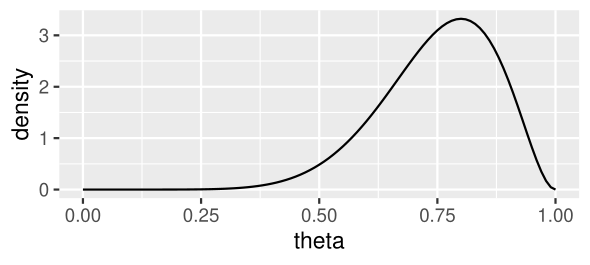

We’d also like a point estimate of the single “best” $\theta$ value. Some options are:

- The posterior expectation
  $$\mathbb{E}[\theta | x] = \int_\Theta \theta \pi(\theta | x) \mathrm{d}\theta$$
- The posterior median
  $$\theta_m \text{ such that } \int_{-\infty}^{\theta_m} \pi(\theta | x) \mathrm{d}\theta = 0.5$$
- The maximum a posteriori (MAP) estimate
  $$\mathop{\mathrm{argmax}}_{\theta \in \Theta} \pi(\theta | x)$$

Chapter 5 discusses theoretical support for these estimates.

Polling example: summaries continued

Let’s calculate the posterior expectation for the polling example.

A $\text{Beta}(a,b)$ random variable has expectation $\frac{a}{a+b}$. So our $\text{Beta}(x+1, n+1-x)$ posterior has expectation $\frac{x+1}{n+2} = 9/12 = 0.75$.

This is smaller than the MLE which equals $x/n = 0.8$.

In fact it’s a weighted average of the MLE and the prior expectation of 0.5:
$$\mathbb{E}[\theta | x] = \lambda \hat{\theta} + (1-\lambda) \mathbb{E}[\theta]$$
(for some $\lambda \in [0,1]$ depending on $x$ and $n$). See Problem 1.4 for more details and proof.

For large $n$, $\mathbb{E}[\theta | x] \to \hat{\theta}$: the large amount of data outweighs the prior information. Chapter 8 proves general convergence results along these lines.

Polling example: JAGS

Bayesian calculations with a conjugate prior can be fairly simple. However for most problems there is no conjugate prior, and computer software is needed, such as JAGS (see Chapter 4).

JAGS outputs a sample of $\theta$ values from the posterior. These can be used to approximate various summaries e.g. density plot, posterior expectation. This approach is known as Monte Carlo.

Polling example: other questions

1.4 Philosophical interpretations

Bayesian statistics requires specifying a prior distribution, and produces a posterior distribution. What do these mean?

They are typically interpreted as representing beliefs. The prior distribution represents our prior beliefs about the parameters before seeing the data. For instance $\mathbb{P}(\theta > 0) = 0.5$ says our prior belief is that it’s equally likely that $\theta$ is positive or negative.

The posterior distribution represents our updated beliefs after we have observed the data. For instance $\mathbb{P}(\theta > 0 | x) = 0.9$ says our updated belief, based on data $x$, is that there is a 90% probability that $\theta$ is positive.

These beliefs are subjective. Another statistician may have different prior beliefs e.g. $\mathbb{P}(\theta > 0) = 0.1$. They will then have different conclusions after observing the data.

Bayesian statistics is said to use the subjective interpretation of probability.

Probability Interpretations

Probability is a well-defined area of mathematics – there’s no major debate about its axioms / results.

But how do we interpret what probability calculations mean about the real world? Three popular interpretations are below. There’s lots of ongoing philosophical debate about their strengths and weaknesses.

#### Subjective interpretation

Probability represents subjective beliefs about the real world. It can be derived from an axiomatic theory on decision making under uncertainty (not covered in this course!), and used to make rational decisions from incomplete and noisy observations. Fundamentally, probabilities relate to our beliefs, not to real physical properties. Used in Bayesian statistics, which is all about updating beliefs correctly.

#### Frequentist interpretation

Probabilities represent long-run frequencies of random events. So $\mathbb{P}(\text{coin lands on heads}) = 0.5$ means
$$\lim_{\text{number of trials} \to \infty} \frac{\text{observed heads}}{\text{number of trials}} = 0.5.$$
Fundamentally, probabilities relate to real physical properties over repeated trials. Used in frequentist statistics, which is all about long run behaviour of statistical methods.

#### Classical interpretation

Probabilities are based on some underlying equally likely events, which are given equal probabilities. For instance $\mathbb{P}(\text{coin lands heads}) = \mathbb{P}(\text{coin lands tails}) = 0.5$. Probabilities of more complex events can be built up from these e.g. probability of getting 5 heads in a row. Useful to avoid philosophical issues about probability when there really are equally likely events e.g. dice/card games.

Probability Interpretations and Statistics

Bayesian statistics uses the subjective interpretation of probability. Under this it makes sense for $\theta$ to be a random variable: it represents our beliefs about parameter values. We can then apply probability theory to $\theta$, in particular Bayes theorem.

Under the frequentist interpretation $\theta$ is usually not a random variable – because there usually aren’t repeated trials giving different $\theta$ values. Frequentist statistics treats $\theta$ as an unknown constant value. The aim is to try to get good long term behaviour under repeated trials with different datasets. This is the basis of frequentist methods like confidence intervals and $p$-values.

(We’ll see Bayesian alternatives to these methods later.)

1.5 Pros and cons of Bayesian statistics

Disadvantages of Bayesian statistics:

- Sometimes difficult to express prior beliefs as a probability distribution
- Conclusions can be sensitive to choice of prior distribution.
- Computing/approximating the posterior can be difficult (extremely difficult before 1990s computer methods!)
- Philosophical reasons. For example: some people argue against subjectivity in scientific inference.

Advantages of Bayesian statistics

- Valid for small amounts of data, while frequentist methods (like maximum likelihood) usually rely on asymptotic justification assuming large data.
- Good at capturing parameter uncertainty, especially for models with many parameters (e.g. in machine learning) where frequentist confidence intervals are not sufficient.
- Helpful when we have prior information we wish to incorporate in the analysis.
- Computational reasons: Bayesian methods are sometimes more computationally tractable than frequentist methods.
- Frequentist performance: as we will see in later chapters, Bayesian methods often have good frequentist properties. Indeed Bayesian methods can be seen as a way of deriving estimators to investigate using frequentist methods.
- Philosophical reasons. Frequentist methods try to get good performance under long run repetitions of an analysis. Less convincing for one-off analyses e.g. who will win a particular football match? what is the mass of Saturn?
- Practical reasons. Both frequentist and Bayesian methods are in common use and have advantages in particular applications. It’s good to know both!

Chapter 2 - Priors

In a Bayesian analysis the statistician must specify their prior knowledge about the parameters in the form of a prior distribution. This chapter covers several methods to do this.

The choice of prior distribution is important because it can have a large influence on the results of the analysis. Also there is no standard method to pick the prior. Using judgement is crucial!

Chapter contents:

1. Hyper-parameters and prior support
2. Conjugate priors
3. Subjective priors (capturing informative prior knowledge)
4. Vague priors
5. Objective priors (capturing lack of prior knowledge)
   - Improper priors
   - Laplace’s prior
   - Jeffreys prior

2.1 Hyper-parameters and prior support

Suppose we need to pick a prior distribution for parameters $\theta$.

We can often split this into two steps:

1. Choose a family of distributions  
   (e.g. a normal distribution)
2. Choose a specific distribution within this family  
   (e.g. a $\mathcal{N}_1(3,0.5^2)$ distribution)

Step 2 requires choosing specific values for the hyper-parameters of the distribution e.g. the mean and variance of a normal distribution. We use the term hyper-parameters here to avoid confusion with the parameters $\theta$.

Similarly we will have hyper-parameters for the posterior distribution. In the earlier polling example, we had a $\text{Beta}(9,3)$ posterior distribution. This had family Beta and hyper-parameters 9 and 3.

Prior support

An important consideration in choosing a prior family is that its support matches the range of possible values for $\theta$.

(Recall the support of a distribution is the set of values with non-zero pdf/pmf.)

#### Examples

1. Is a normal distribution a good prior family for the proportion of people with blue eyes?  
   No: the proportion is in $[0,1]$, but the normal distribution has support $\mathbb{R}$.
2. Is a Gamma distribution a good prior family for the speed of 100m runners?  
   Yes: speeds are positive, and the Gamma distribution has support $(0,\infty)$.
3. Is a Poisson distribution a good prior family for the number of winning lottery tickets out of 5 that I’ve bought?  
   No: the number of winning tickets is in $\{0,1,2,3,4,5\}$, but the Poisson distribution has support all non-negative integers.

2.2 Conjugate prior distributions

Conjugate priors are a mathematically neat way to select a prior family, which simplifies the process of computing the posterior.

**Definition 2.1**. A family $\mathcal{F}$ of distributions is said to be conjugate for the model $\{f(\cdot|\theta),\theta\in\Theta\}$ if every prior distribution in $\mathcal{F}$ gives a posterior distribution in $\mathcal{F}$:
$$\pi(\theta) \in \mathcal{F} \Rightarrow \pi(\theta|x) \in \mathcal{F},\quad\forall x\in\mathcal{X}.$$

The main advantage of using a conjugate prior distribution is that the posterior distribution typically has a known expression. Firstly, we know it is in $\mathcal{F}$. Secondly, there is usually a simple formula to calculate its hyper-parameters (e.g. see next slide).

Therefore many quantities of interest, for example the posterior mean, have a closed form expression.

However, the existence of a conjugate prior distribution is (mostly) limited to the case of IID observations from a simple distribution e.g. normal, binomial, Poisson.

#### Example:

For a binomial model, the Beta distribution is conjugate. (See Chapter 1, and Problem 1.4.)

#### Remark 1

Even when no conjugate prior exists, standard conjugate priors can be useful e.g. in designing Gibbs samplers (see Chapter 4).

#### Remark 2

Wikipedia has a detailed list of conjugate priors: https://en.wikipedia.org/wiki/Conjugate_prior#Table_of_conjugate_distributions.

Example: Gaussian model with unknown mean

Consider the IID model $X_k \sim \mathcal{N}_1(\theta, \sigma^2)$ for $k = 1,2,\ldots,n$.

Suppose $\sigma>0$ is a known fixed constant, and $\theta$ is an unknown parameter with prior
$$\theta \sim \mathcal{N}_1(\mu_0, \sigma_0^2)$$
for known constants $\mu_0, \sigma_0>0$ (prior hyper-parameters).

Then the posterior distribution is
$$\theta|x \sim \mathcal{N}(\mu_n, \sigma^2_n)$$
where the observed data are $x = (x_1, x_2, \ldots, x_n) \in \mathbb{R}^n$, and
$$\begin{gathered}
\mu_n= \lambda_n \mu_0+(1-\lambda_n) \bar{x}_n,\hspace{1.0em} \sigma_n^2=\frac{\sigma^2}{n_0+n} \\
\bar{x}_n=\frac{1}{n}\sum_{k=1}^n x_k,\quad \lambda_n=\frac{n_0}{n_0+n}\in (0,1),\quad n_0=\frac{\sigma^2}{\sigma_0^2}.
\end{gathered}$$
The posterior hyper-parameters are $\mu_n$ and $\sigma_n^2$.

*Proof:* See Problem 2.7 (long derivation!)

#### Comments

- So a Gaussian prior for $\theta$ is conjugate for this model.
- When both $\theta$ and $\sigma$ are parameters, there is also a conjugate prior, but it is more complicated.
- The posterior mean $\mu_n$ is a weighted average between the empirical mean $\bar{x}_n$ and the prior mean $\mu_0$. So the posterior balances information from the prior and from the observations.
- When $n$ is large, $\mu_n \approx \bar{x}_n$ and $\sigma_n^2 \approx \sigma^2/n \to 0$ and the impact of $\mu_0, \sigma_0$ on the posterior distribution is negligible. (See Chapter 8 for related general results.)

Gaussian model with unknown mean

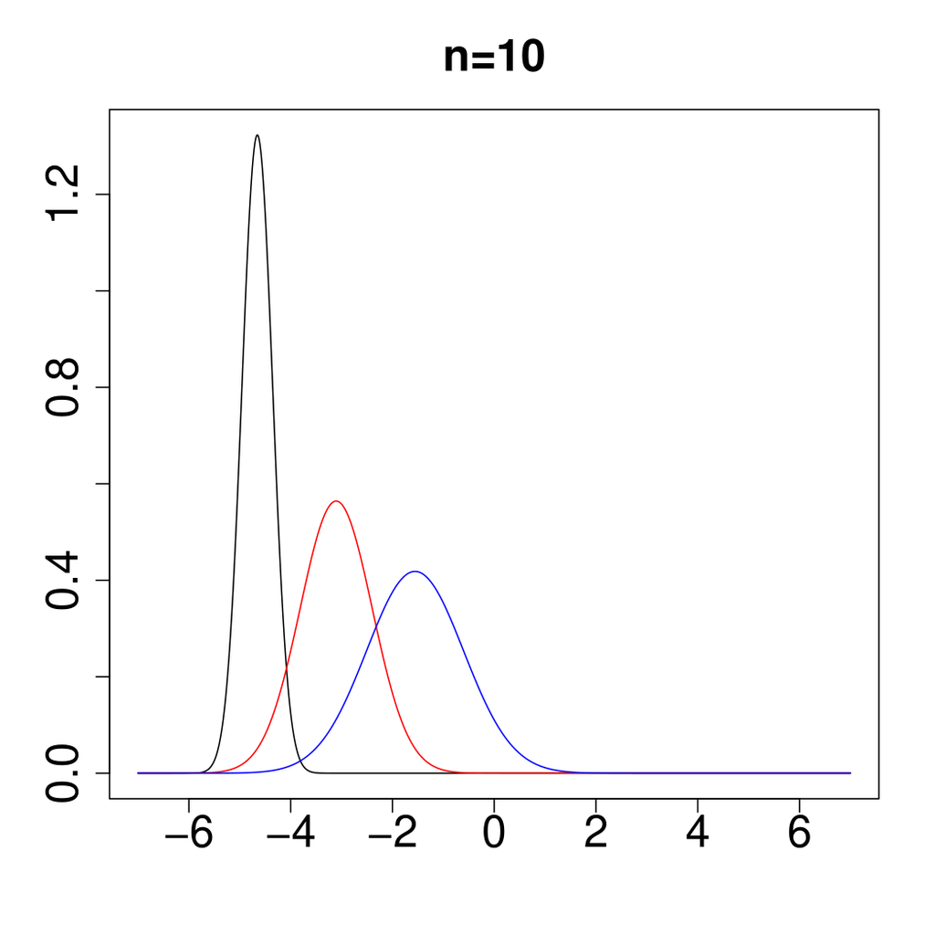

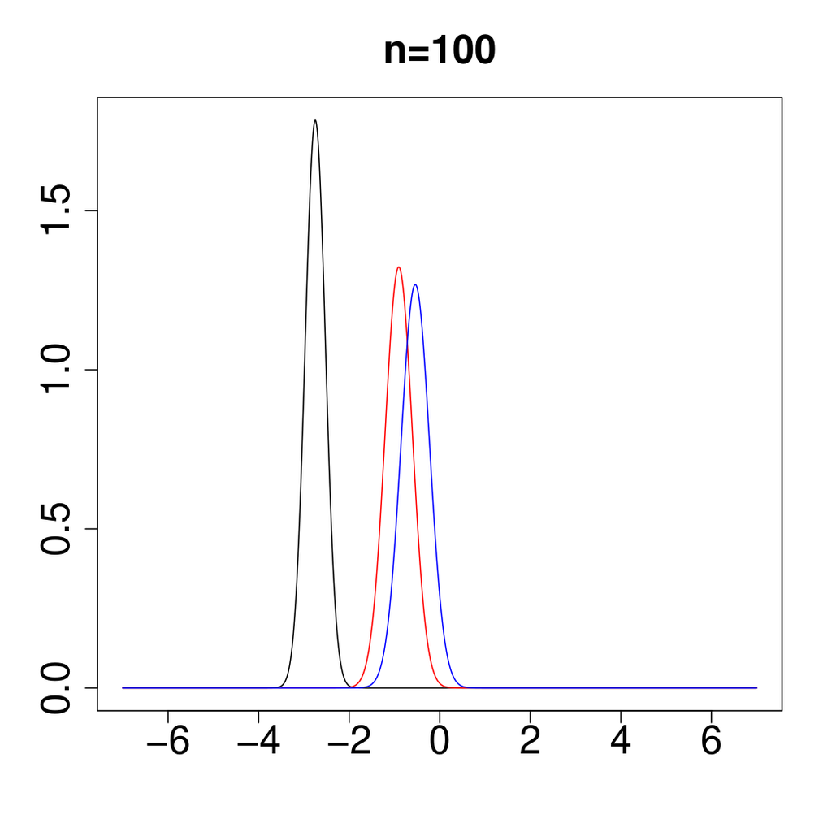

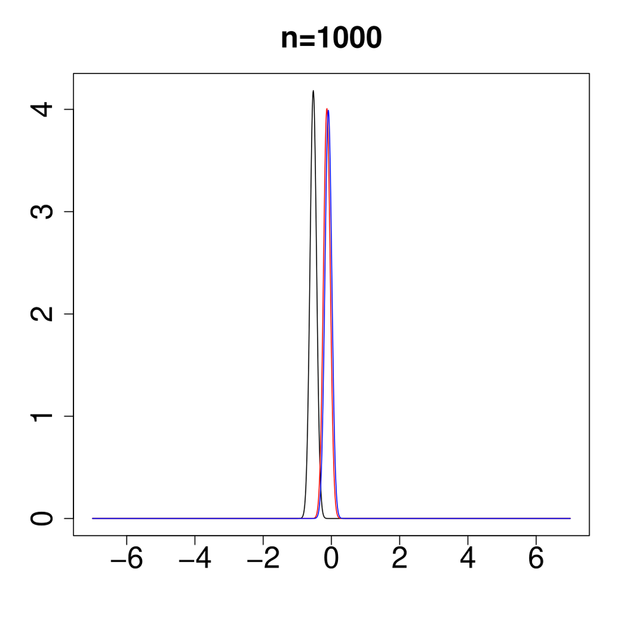

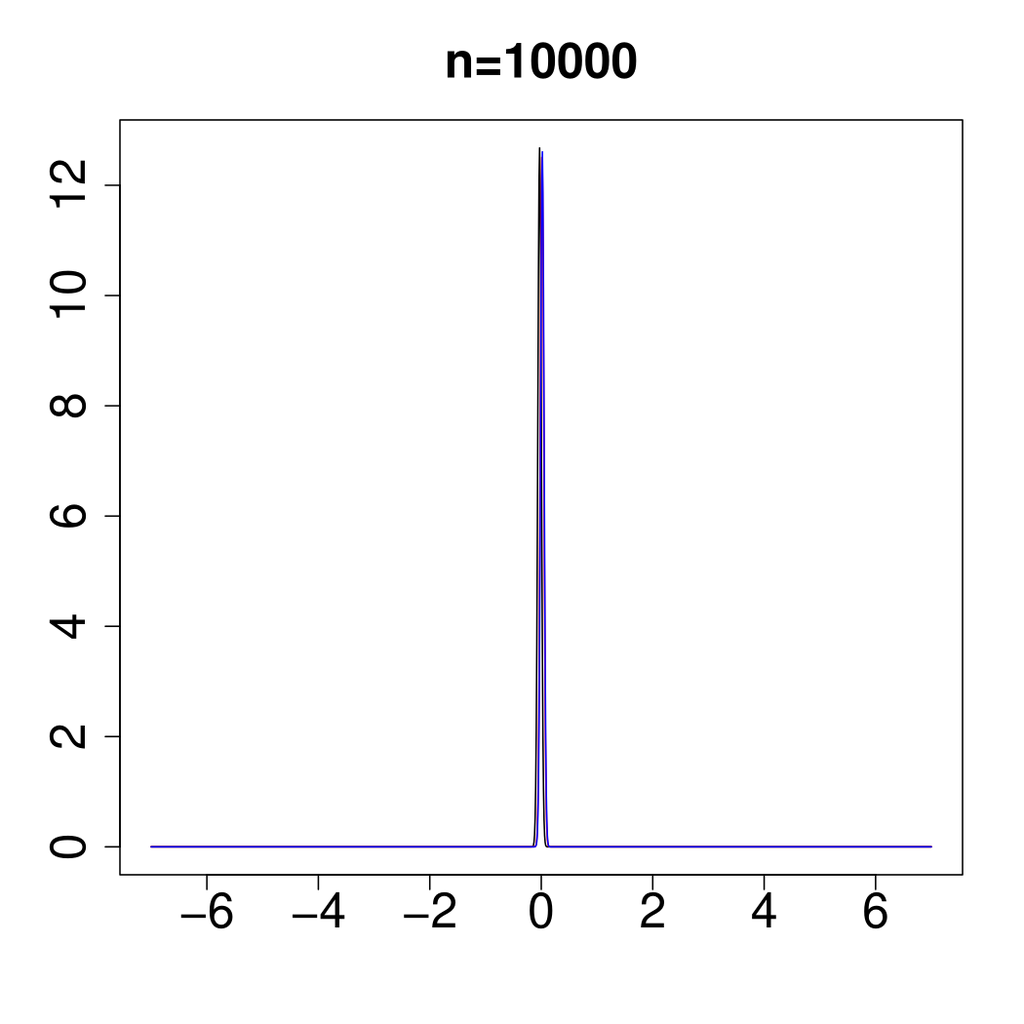

Posterior distributions for $n\in\{10,100,1\,000,10\,000\}$ and for $\sigma^2_0=0.1$ (black), $\sigma^2_0=1$ (red) and $\sigma^2_0=10$ (blue). The observations are realisations of i.i.d. $\mathcal{N}_1(0,10)$ random variables and $\mu_0=-5$. (So the true parameter is $0$ and the prior mean is $-5$.)

2.3 Subjective priors

A subjective prior is a distribution which represents your beliefs about the parameters. Beliefs might be based on your experience, expert advice, or previous studies.

It’s subjective because different people might have different beliefs! When using this approach, the choice of which prior to use is a matter of opinion.

We could make a subjective choice of both prior family and hyper-parameters. Or we could pick our prior family using other considerations – e.g. a conjugate prior – and then pick the hyper-parameters subjectively.

Later we’ll consider approaches that aim to be less subjective (vague priors) or to avoid subjectivity (non-informative priors).

Subjective priors: example

Suppose we have a parameter $\theta$ which represents the mean house price in Bristol in 2030 (in thousands of pounds). This might be part of a regression model for house prices over time, including into the future.

Some considerations we could use to get a subjective prior are:

- What are some suitable prior families?
- Can we give a value for $\mathbb{E}[\theta]$ - what do we think is a typical value for $\theta$?
- Can we give a value for $\text{Var}[\theta]$ - how much uncertainty do we have about $\theta$?
- Can we give an interval $[a,b]$ such that $\mathbb{P}(a < \theta < b) = 0.95$?
- Do we think $\theta$ should have a symmetric distribution around its mean?
- Can we access any expert opinions?
- Do we have any previous studies which might inform our beliefs?
- What values of $\theta$ seem completely implausible?

For instance, I might argue:

- The mean house price in 2024 is around 300.
- I think there’s a 95% chance that annual increases in house prices are between -2% (economic crash and/or lots of house building) and 15% (housing shortage and/or high inflation).
- This gives a range of $[265, 694]$.
- This approximately matches a $\mathcal{N}_1(480, 100^2)$ distribution  
  (truncated to positive values to avoid negative house prices).

Different beliefs could produce very different prior distributions!

2.4 Vague priors

What if we have some background knowledge, but not enough to confidently pick a subjective prior? One approach is to use a vague prior: just use beliefs about what scale of values is plausible or implausible. Apart from the plausible range, most of the information should come from the data.

For instance, we might believe that a mean house price above $1000$ is implausible. Then we could pick a prior distribution which gives low probability outside this range e.g. $\text{Exp}(0.005)$.

2.5 Objective priors

How can we apply Bayesian approaches when no prior information is available?

One possibility is to use a non-informative (or “objective”) prior distribution, designed to capture lack of knowledge about the parameters. Several possible choices have been proposed. We will look at two:

- Laplace’s prior
- Jeffreys prior.

Along the way we will cover some background material:

- Improper densities
- Change of variables (revision)

Improper densities

Usually a probability density function $\pi(\theta)$ must satisfy:
$$\begin{aligned}
\pi(\theta) &\geq 0&\qquad\text{(2.1)}\\
\int_\Theta \pi(\theta) \mathrm{d}\theta &= 1&\qquad\text{(2.2)}\end{aligned}$$
We’ll refer to this as a proper density.

In Bayesian statistics we sometimes allow improper densities, which replace (2.2) with
$$\int_\Theta \pi(\theta) \mathrm{d}\theta = \infty.$$

Improper densities are hard to interpret e.g. they allow probabilities greater than 1!

However they can be useful as priors in Bayes theorem. A Bayesian analysis with an improper prior can result in a proper posterior, giving sensible probabilities.

We’ll see that many non-informative prior densities are improper.

#### Remarks

- Improper probability mass functions can be defined similarly.
- We can’t use the proportionality method from Theorem 1.1 with improper priors. Its proof assumed the posterior was proper, which may not be true here! But we can use a similar result.

Proportionality method 2

A proportionality method which allows improper priors is as follows.

**Theorem 2.1**. *Fix a particular observation $x$. Assume $\pi(\theta) f(x|\theta) \propto q(\theta)$ for all $\theta \in \Theta \subseteq \mathbb{R}^d$, where $q(\theta)$ is a proper probability density function. Then $\pi(\theta | x) = q(\theta)$.*

#### Proof

We have $\pi(\theta) f(x|\theta) = c q(\theta)$ for some finite constant $c > 0$. Hence
$$m(x) = \int_{\Theta} \pi(\theta) f(x|\theta) \mathrm{d}\theta = c \int_{\Theta} q(\theta) \mathrm{d}\theta = c.$$
So the posterior is
$$\pi(\theta | x) = \frac{\pi(\theta) f(x|\theta)}{m(x)} = \frac{c q(\theta)}{c} = q(\theta).$$

#### Note

The proof holds regardless of whether $\pi(\theta)$ is proper or improper.

In particularly complicated situations you may be unsure whether this theorem applies. In this case you can calculate $m(x)$ and apply Bayes theorem directly.

Laplace’s prior

Laplace was the first to use non-informative techniques, with a non-informative prior density $\pi(\theta)$ putting equal value on every $\theta$:
$$\pi(\theta) \propto 1,\quad\forall\theta\in\Theta.$$
We’ll call this Laplace’s prior.

If $\Theta$ is unbounded then $\pi(\theta)$ can be improper, and is sometimes called “the improper uniform prior”.

#### Example

Consider the Gaussian model
$$X \sim \mathcal{N}_1(\theta,1),\quad\theta\in\mathbb{R}.$$
Then, Laplace’s prior gives a proper posterior density:
$$\theta|(X=x) \sim \mathcal{N}_1(x, 1),\quad\forall x\in\mathbb{R}.$$
See next slide for the derivation.

#### Remarks

- This is an example of an improper prior giving a proper posterior.
- In the above example, the posterior under Laplace’s prior corresponds to the limit when the prior variance goes to infinity in a conjugate analysis.

Example details

Consider the improper uniform prior $\pi(\theta)=1$.

Then
$$\begin{aligned}
\pi(\theta) f(x|\theta) &= f(x|\theta) \\
&= \frac{1}{(2\pi)^{1/2}} \exp \left[ -\tfrac{1}{2} (x-\theta)^2 \right]
\end{aligned}$$
The last line is $f(x|\theta)$. We need to consider it as a function of $\theta$ with $x$ fixed. In this case it equals the density for $\theta \sim \mathcal{N}_1(x, 1)$, which is a proper density.

Thus using Theorem 2.1 we have a proper posterior: $\theta | x \sim \mathcal{N}_1(x,1)$.

#### Exercise:

We assumed $\pi(\theta)=1$. Check we get the same result if we instead assume $\pi(\theta)=c$ for some constant $c>0$.

Change of variables (revision from Statistics 2)

Consider a random vector $\theta$ taking values in $\mathbb{R}^d$ with density $\pi(\theta)$, and a function $g:\mathbb{R}^d\rightarrow\mathbb{R}^d$. Then $\eta = g^{-1}(\theta)$ is a change of variables of $\theta$.

Throughout this chapter we’ll assume $g$ is a bijection and differentiable. Then the density of $\eta$ is
$$\begin{aligned}
\pi^*(\eta) & = | \det J(\eta) | \pi(\theta) \\
& = | \det J(\eta) | \pi(g(\eta))
\end{aligned}$$
where $J(\eta)$ is the Jacobian matrix for $g$:
$$J(\eta) = \begin{pmatrix}
\frac{\partial g_1}{\partial \eta_1} & \frac{\partial g_1}{\partial \eta_2} & \cdots & \frac{\partial g_1}{\partial \eta_d} \\
\frac{\partial g_2}{\partial \eta_1} & \frac{\partial g_2}{\partial \eta_2} & \cdots & \frac{\partial g_2}{\partial \eta_d} \\
\vdots & \vdots & \ddots & \vdots \\
\frac{\partial g_d}{\partial \eta_1} & \frac{\partial g_d}{\partial \eta_2} & \cdots & \frac{\partial g_d}{\partial \eta_d} \\
\end{pmatrix}$$
and the derivatives are evaluated at $\eta$.

#### Sketch justification (not examinable)

Consider the case where $d=1$. Then under the proposed density for $\eta$ we get
$$\begin{aligned}
\mathbb{P}(\eta\in A) &= \int_{\eta \in A} \pi^*(\eta)\,\mathrm{d}\eta \\
&= \int_{g^{-1}(\theta) \in A} \left| \frac{d\theta}{d\eta} \right| \pi(\theta)\,\mathrm{d}\eta \\
&= \int_{g^{-1}(\theta) \in A} \pi(\theta)\,\mathrm{d}\theta & \text{(by change of variables rule for integrals)}
\end{aligned}$$
So we get the same probability by integrating (over appropriate sets):

- $\pi^*(\eta)$ with respect to $\eta$
- $\pi(\theta)$ with respect to $\theta$

Laplace’s prior: reparameterisation issues

The most important problem with Laplace’s prior is the problem of invariance under reparameterisation.

Suppose $\pi(\theta) \propto 1$ (Laplace’s prior). Consider a change of variables $\eta=g^{-1}(\theta)$. Then $\eta$ has prior density
$$\pi^*(\eta) \propto |\det J(\eta)| \pi(g(\eta)) \propto |\det J(\eta)|.$$
So the prior density $\pi^*(\eta)$ may not be constant. Hence it’s no longer non-informative in the sense of Laplace – even though the prior information available is exactly the same!

#### Remark

Making a change of variables to a parameter is known as a reparameterisation.

Laplace’s prior reparameterisation example

Suppose $\Theta = [0,1]$. Laplace’s prior density is $\pi(\theta) = 1$, the $\mathcal{U}(0,1)$ distribution.

Let $\eta = \theta^{1/2}$, so $g(\eta) = \eta^2$ and $\frac{\mathrm{d}g}{\mathrm{d}\eta} = 2\eta$.

Then the prior density on $\eta \in [0,1]$ is
$$\begin{aligned}
\pi^*(\eta) & = \left| \frac{\mathrm{d}g}{\mathrm{d}\eta} \right| \pi(g(\eta)) \\
& = 2 \eta \times 1 = 2 \eta
\end{aligned}$$

So a uniform prior on $\theta$ gives a non-uniform prior on $\eta$!

Thus Laplace’s approach suggests we have no prior information about $\theta$, but we do have prior information about $\theta^{1/2}$! This is an undesirable property.

Jeffreys prior

Jeffreys prior is based on the idea that a non-informative prior density is a prior density derived entirely from the model $\{f(\cdot|\theta),\theta\in\Theta\}$ since this is the only available information. So there is no need for a subjective choice.

**Definition 2.2**. For a given parametric model $\{f(\cdot|\theta), \theta\in\Theta\}$, the Jeffreys prior is defined by the density
$$\pi_J(\theta) \propto \sqrt{\det(\mathcal{I}(\theta))},\quad\theta\in\Theta$$
with $\mathcal{I}(\theta)$ the Fisher Information matrix.

Recall that the Fisher information is a $d \times d$ matrix with row $i$ column $j$ entry:
$$\mathbb{E}\bigg[\frac{\partial\log f(X|\theta)}{\partial \theta_i}\frac{\partial\log f(X|\theta)}{\partial \theta_j}\bigg].$$
(2.3) The expectation is over $X$ conditional on $\theta$. Under some weak assumptions (which we assume always hold) this equals:
$$\mathbb{E}\left[ -\frac{\partial^2}{\partial \theta_i \partial \theta_j} \log f(X | \theta) \right].$$
(2.4)

#### Remark

In general (2.3) is more useful for theory (proofs etc), and (2.4) is more useful for examples and applications.

Jeffreys prior: invariance

Compared to Laplace’s prior, the Jeffreys prior has the advantage of being invariant to reparameterisation, as shown in the next result.

**Proposition 2.1**. Assume that $\theta$ has prior density $\pi_J(\theta)$. Then the reparameterisation $\eta:=g^{-1}(\theta)$ has density
$$\pi^*(\eta)= |\det J(\eta)|\pi_J(g(\eta)) \propto \sqrt{\det(\tilde{\mathcal{I}}( \eta))}$$
where $\tilde{\mathcal{I}}(\eta)$ has row $i$ column $j$ entry:
$$\mathbb{E}\left[\frac{\partial \log f(X|g(\eta))}{\partial \eta_i}\frac{\partial \log f(X|g(\eta))}{\partial \eta_j} \right].$$

Note that $:=$ means “is defined as”.  
*Proof:* See next slides.

**Remark:** We conclude that Jeffreys prior is invariant to reparameterisation because we get the same prior by two approaches:

1. Calculate Jeffreys prior for $\theta$, then reparameterise to get a prior for $\eta$.
2. Calculate Jeffreys prior for $\eta$.

**Example:** The Jeffreys prior for the Binomial model is the $\mathrm{Beta}(1/2,1/2)$ distribution. (The derivation appears shortly.) This is different to Laplace’s prior of $\mathcal{U}(0,1)$!

Invariance proof

We’ll just consider the univariate case: $\theta \in \mathbb{R}$.

Using the chain rule
$$\frac{\partial}{\partial \eta} \log f(x | g(\eta))
= \frac{\partial \theta}{\partial \eta}
\frac{\partial}{\partial \theta} \log f(x | \theta) \big|_{\theta = g(\eta)}$$
So the Fisher information for $\eta$ is
$$\begin{aligned}
\tilde{\mathcal{I}}(\eta) & =
\mathbb{E}\left[ \left\{
\frac{\partial}{\partial \eta} \log f(X | g(\eta))
\right\}^2 \right] \\
& = \mathbb{E}\left[
\left\{ \frac{\partial \theta}{\partial \eta} \right\}^2
\left\{
\frac{\partial}{\partial \theta} \log f(X | \theta) \big|_{\theta = g(\eta)}
\right\}^2
\right] \\
& = \left( \frac{\partial \theta}{\partial \eta} \right)^2
\mathcal{I} [g(\eta)] \\
\Rightarrow
\sqrt{\tilde{\mathcal{I}}(\eta)}
& = \left| \frac{\partial \theta}{\partial \eta} \right|
\sqrt{\mathcal{I}(g(\eta))}
\end{aligned}$$
Note that in the univariate case, $\det \mathcal{I}(\theta) = \mathcal{I}(\theta)$. So we have
$$\begin{aligned}
\tilde{\pi}_J(\eta) \propto
\left| \frac{\partial \theta}{\partial \eta} \right| \pi_J(g(\eta))
\end{aligned}$$
So the following are equivalent, as required:

- Deriving the Jeffreys prior for $\eta$
- Deriving the Jeffreys prior for $\theta$ then making a change of variables to $\eta$

#### Remark

The multivariate case is very similar but uses multivariate calculus.

Binomial example Jeffreys prior derivation

Suppose $X$ is a $\text{Binomial}(m,\theta)$ random variable, with known $m\geq 1$ and unknown parameter $\theta\in\Theta:=[0,1]$. Recall $\mathbb{E}[X] = m\theta$.

The likelihood is
$$f(x | \theta)=\binom{m}{x} \theta^{x}(1-\theta)^{m-x}.$$
Therefore
$$\begin{aligned}
\log f(x|\theta) & = \log \binom{m}{x} + x \log \theta + (m-x) \log (1-\theta) \\
\Rightarrow \frac{\partial}{\partial \theta} \log f(x|\theta) & = \frac{x}{\theta} - \frac{m-x}{1-\theta} \\
\Rightarrow \frac{\partial^2}{\partial \theta^2} \log f(x|\theta) & = -\frac{x}{\theta^2} - \frac{m-x}{(1-\theta)^2}
\end{aligned}$$

Hence the Fisher information is
$$\begin{aligned}
\mathbb{E}\left[-\frac{\partial^2}{\partial \theta^2} \log f(X|\theta) \right]
& = \frac{\mathbb{E}[X]}{\theta^2} + \frac{m-\mathbb{E}[X]}{(1-\theta)^2} \\
& = \frac{m\theta}{\theta^2} + \frac{m(1-\theta)}{(1-\theta)^2} \\
& = m \left[ \frac{1}{\theta} + \frac{1}{1-\theta} \right] \\
& = m \frac{1}{\theta(1-\theta)}
\end{aligned}$$
So the Jeffreys prior is $\pi_J(\theta) \propto \theta^{-1/2} (1-\theta)^{-1/2}$, which is a Beta$(1/2,1/2)$ distribution.

Jeffreys prior: remarks

- The Jeffreys prior is often improper. Be careful to check if the resulting posterior is proper!
- The Jeffreys prior is not always easy to derive analytically, especially in the multivariate case.
- Jeffreys prior is invariant to reparameterisation. Does this mean it perfectly captures prior uncertainty? Many statisticians would argue no.
- Harold Jeffreys proposed this prior distribution in 1946, developing earlier work with Dorothy Wrinch. He later wrote *“I should like to put on record my appreciation of the substantial contribution she made to [our joint] work, which is the basis of all my later work on scientific inference.”*

General remarks on the objective approach

- Careless use of improper prior densities is dangerous. In particular, it may be that the posterior density does not define a proper probability distribution.
- Improper prior densities should be avoided for hypothesis testing (see Chapter 6).
- Can lack of information truly be encoded in a prior distribution? Some current philosophical research argues no(!): such “deep uncertainty” must be captured outside probabilistic methods.

Chapter 3 - Credible sets

Point estimates of parameters give a single “most likely” parameter value. For scalar parameters, statisticians also often provide interval estimates, giving a range of reasonably likely values.

Frequentist statistics uses confidence intervals. Here we discuss the Bayesian alternative, credible intervals, and the more general credible sets. The latter allows multivariate parameters.

Chapter contents:

1. Credible sets definition
2. Types of credible set/interval: symmetric, quantile, highest posterior density
3. Comparison with confidence intervals

3.1 Credible sets definition

**Definition 3.1**. Let $\alpha\in(0,1)$. A subset $C\subseteq\Theta$ is an $(1-\alpha)$-credible set for $\theta$ if
$$\mathbb{P}(C|x) = 1-\alpha.$$

That is, a credible set $C$ should have a posterior probability of $1-\alpha$.

#### Remarks

- $\alpha$ is sometimes called the level of the credible set.
- A $(1-\alpha)$ credible set is often referred to as a $100(1-\alpha)$% credible set e.g. $\alpha=0.05$ gives a 95% credible set.
- When $\theta$ is univariate and $C$ is an interval, it is known as a credible interval.
- Multivariate credible sets can be difficult to interpret. Instead it’s common to calculate a credible set for each individual parameter.
- A credible set may not always exist for a given $\alpha$. This is common for discrete parameters.
- For continuous parameters, there are usually multiple possible credible sets.

Examples

Below are three 50% credible intervals for the posterior distribution $\mathcal{N}_1(3,1)$: $[3, \infty), (-\infty,3], [2.33, 3.67]$.

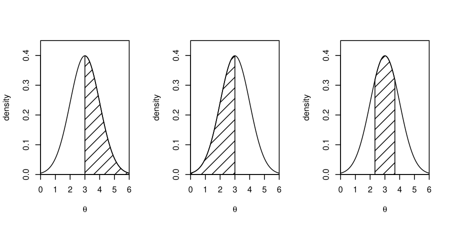

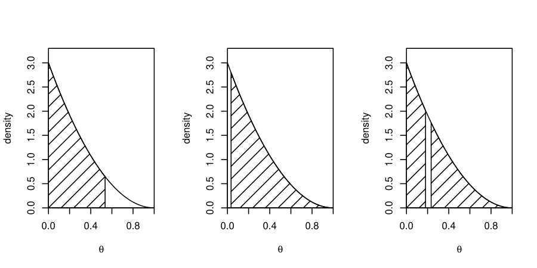

This illustrates that credible sets/intervals are usually not unique. Which of these credible sets seems most useful?

Next we consider several possible approaches to choosing a unique credible interval.

3.2 Types of credible set

Consider a scalar parameter $\theta \in \Theta \subseteq \mathbb{R}$ with posterior density $\pi(\theta|x)$ and a particular choice of Bayesian point estimate $\hat{\theta}$.

**Definition 3.2**. *The $1-\alpha$ symmetric credible interval for $\theta$ is a $1-\alpha$ credible interval of the form $[\hat{\theta} - \gamma_\alpha, \hat{\theta} + \gamma_\alpha]$ for some value $\gamma_\alpha$.*

#### Remarks

- An advantage of symmetric credible intervals is that they always contain $\hat{\theta}$.
- The rest of the notes take $\hat{\theta}$ to be the posterior mean.
- It can be hard to extend this definition to discrete or multivariate parameters.
- Sometimes there is no symmetric credible interval $C \subseteq \Theta$: a symmetric interval may need to extend beyond $\Theta$! (see example later)

Quantile credible intervals

Consider a scalar parameter $\theta \in \Theta \subseteq \mathbb{R}$ with posterior density $\pi(\theta|x)$. Let $F(\theta)$ be the cumulative distribution function of the posterior distribution.

**Definition 3.3**. *The $1-\alpha$ quantile credible interval for $\theta$ is the interval $C = [a,b]$ where $a = F^{-1}(\alpha/2)$ and $b = F^{-1}(1-\alpha/2)$.*

#### Remarks

- We have $\mathbb{P}(\theta \leq a | x) = \mathbb{P}(\theta \geq b | x) = \alpha/2$.
- $F^{-1}$ is known as the quantile function, and $F^{-1}(p)$ is the $p$-quantile of the posterior distribution. So the endpoints of the interval are both quantiles.
- Quantile credible intervals may not exist if $F^{-1}$ is not continuous e.g. for discrete parameters.

Highest posterior density sets

**Definition 3.4**. A credible set $C$ is a highest posterior density (HPD) set for the posterior density $\pi(\theta|x)$ if
$$C= \{ \theta\in \Theta: \pi(\theta|x)\geq \gamma_\alpha \}$$
for some value $\gamma_\alpha$.

**Remarks:**

- $C$ must still satisfy $\mathbb{P}(C|x) = 1-\alpha$.
- For univariate $\theta$, HPD sets are often intervals, known as HPD intervals.
- We have not shown that a HPD set exists for every $\alpha$. Existence can be proved when $\pi(\theta|x)$ is continuous in $\theta$ (using the intermediate value theorem.)
- In some cases the HPD can be calculated exactly (see example later)
- The HPD for univariate $\theta$ must typically be calculated by computer, which is usually quick to do. (For MCMC output use `HPDinterval` in R.)
- Finding HPD sets for multivariate $\theta$ is harder. It’s more common to find separate HPD intervals for each individual parameter.

Example

For the $\mathcal{N}_1(3,1)$ posterior, all 3 types of $50\%$ credible interval are the same(!): $[2.33, 3.67]$ (to 2dp).

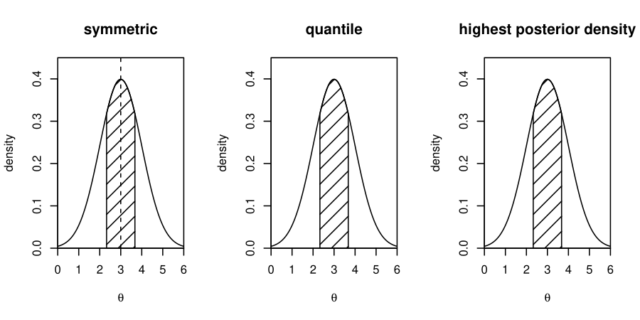

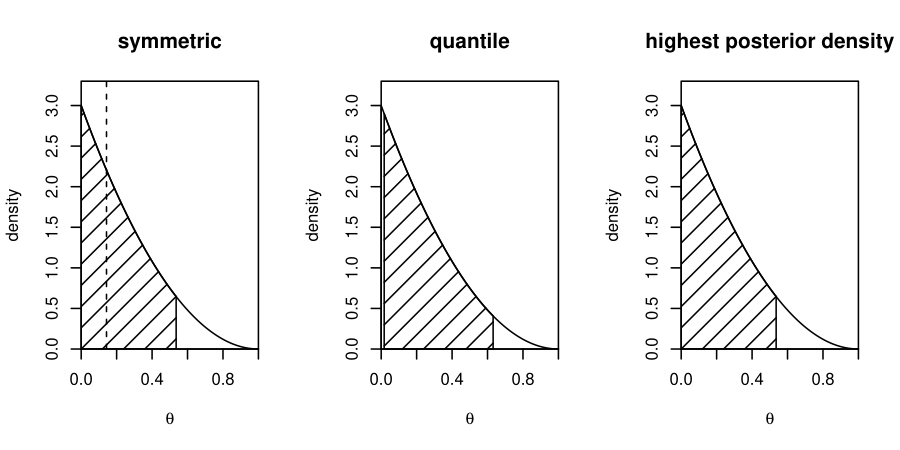

In this example, the symmetric interval lower endpoint lies outside our parameter space $[0,1]$! This is an undesirable feature.

Credible intervals for Gaussian posteriors

**Theorem 3.1**. Consider the posterior density $\theta \sim \mathcal{N}_1(\mu,\sigma^2)$. The interval
$$C_\alpha = [\mu - q_{1-\alpha/2} \sigma, \mu + q_{1-\alpha/2} \sigma]$$
is a $(1-\alpha)$ credible interval, which is a symmetric, quantile and HPD interval.

Recall $q_{1-\alpha/2}$ is the $(1-\alpha/2)$-quantile of the $\mathcal{N}_1(0,1)$ distribution.

See Problem 3.3 for proof.

#### Comments

- Exactly Gaussian posteriors can occur due to conjugacy or from asymptotic arguments - see Chapter 8.
- The most common $\alpha$ value is $0.05$ (just a convention - no better reason!) It’s useful to remember this gives $q_{1-\alpha/2} \approx 1.96$. So $C_{0.05} \approx [\mu - 1.96\sigma, \mu + 1.96\sigma]$.

3.3 Comparison with confidence intervals

The frequentist counterpart of credible intervals are *confidence intervals*.

Suppose we have a method for constructing an interval of parameter values $C(x) \subseteq \Theta$ given data $x$. The frequentist approach considers the performance of this method under repeated sampling of data $x$ from the model under a parameter value $\theta_0$. A $(1-\alpha)$-confidence interval has the property that $\theta_0 \in C(x)$ with probability $1-\alpha$. This should hold for any $\theta_0$.

#### Remark

Confidence/credible intervals both tell us something about the uncertainty around parameter estimates. But they have very different definitions and interpretations! In practice they sometimes give similar numerical ranges.

#### Example

For a univariate parameter $\theta$, a common $(1-\alpha)$-confidence interval is
$$\Big[\widehat\theta_n-q_{1-\alpha/2}\frac{\hat\sigma}{\sqrt{n}}, \widehat\theta_n+q_{1-\alpha/2}\frac{\hat\sigma}{\sqrt{n}}\Big]$$
where

- $n$ is the sample size
- $\widehat\theta_n$ is an estimate of $\theta$ (e.g. the MLE)
- $\hat\sigma^2$ is an estimate of $\text{Var}(\widehat\theta_1)$
- $q_{1-\alpha/2}$ was defined on the previous page

This is very similar to the Bayesian credible interval. As we’ll see in Chapter 8, the posterior can often be approximated by $\mathcal{N}_1(\widehat\theta_n, \hat\sigma^2 /n)$. Using Theorem 3.1 then gives the same interval.

Chapter 4 - Markov chain Monte Carlo

For conjugate priors, the posterior distribution is available in a simple form that is easy to summarise to give point estimates, credible intervals etc.

However conjugate priors only exist for the simplest models. Most posteriors are too complicated to summarise using purely mathematical methods. This limited the practical application of Bayesian statistics.

Markov chain Monte Carlo (MCMC) algorithms are computer-based methods which allow posteriors to be summarised. They date back to the 1950s, but became popular in Bayesian statistics in the 1990s, and today allow Bayesian statistics to be performed in practice.

This chapter gives an introduction to MCMC algorithms.

A separate document on Blackboard contains an introduction to JAGS: computer software to perform MCMC in practice.

Writing and understanding R and JAGS code is important for the coursework, but will not be part of the exam. However the exam might ask related questions e.g. interpreting some MCMC output plots created using R and JAGS.

Chapter contents

1. Introduction to the Metropolis-Hastings algorithm  
   (a standard MCMC algorithm)
2. Monte Carlo methods
3. MCMC history
4. Discrete state Markov chain theory  
   (mostly recap from Probability 2)
5. Metropolis-Hastings: theory
6. Metropolis-Hastings: practical guidance
7. Gibbs sampling  
   (another standard MCMC algorithm)

4.1 Introduction

First we recap our Bayesian setting. We are interested in the posterior density,
$$\pi_\text{posterior}(\theta) = \frac{\pi_\text{prior}(\theta) L(\theta)}{m}$$
where $\pi_\text{prior}(\theta)$ is the prior density, $L(\theta)$ is the likelihood and
$$m = \int_\Theta \pi_\text{prior}(\theta) L(\theta) \mathrm{d}\theta$$
is the evidence.

#### Remarks

- The notation above is slightly different to earlier chapters. This is to avoid clashes later on in the chapter.
- Typically the prior density and likelihood are easy to calculate. However the evidence $m$ is not, as it’s a complicated high dimensional integral. Therefore $m$ is said to be intractable.

Metropolis-Hastings overview

#### Main result:

For sufficiently large $t$, $\theta_t$ is approximately a sample from the posterior. These samples help us summarise the posterior. (Even when they are not independent samples!)

#### Demo:

https://chi-feng.github.io/mcmc-demo

The user must choose $\Sigma$. Bad choices give bad algorithm performance. Details and guidance later.

Normal random walk Metropolis-Hastings: comments

The algorithm only requires us to calculate the prior density and likelihood, never the intractable evidence $m$ or the posterior density. However the steps are closely related to the posterior.

Bayes theorem is:
$$\pi_\text{posterior}(\theta) = \frac{\pi_\text{prior}(\theta) L(\theta)}{m}$$
So the acceptance probability is
$$\begin{aligned}
\alpha(\theta_{t-1},\tilde{\theta}_t)
&= \min\bigg\{1,\frac{\pi_\text{prior}(\tilde{\theta}_t) L(\tilde{\theta}_t)}{\pi_\text{prior}(\theta_{t-1}) L(\theta_{t-1})}\bigg\} \\
&= \min\bigg\{1,\frac{\pi_\text{posterior}(\tilde{\theta}_t) m}{\pi_\text{posterior}(\theta_{t-1}) m}\bigg\} \\
&= \min\bigg\{1,\frac{\pi_\text{posterior}(\tilde{\theta}_t)}{\pi_\text{posterior}(\theta_{t-1})}\bigg\}
\end{aligned}$$
There’s a ratio of posterior densities, but we never need to calculate the posterior density itself!

Proposals are accepted when they increase the posterior density (optimisation type behaviour).

But some which reduce the posterior density are also accepted (exploration type behaviour).

Chapter preview

The rest of the chapter describes the theory behind Metropolis-Hastings, and other MCMC algorithms. This includes a review of the theory of Markov chains.

Then we use the theory to discuss issues about running MCMC in practice, and present the JAGS software to do this.

4.2 Monte Carlo methods

Monte Carlo is a numerical method to estimate an expectation:
$$\mathbb{E}_\pi[f(X)]$$
Here $X$ is a random variable, $\pi$ is its distribution and $f$ is a function of interest.

Suppose $X_1, X_2, \ldots, X_k$ are IID random variables with distribution $\pi$. Then the law of large numbers gives that
$$\frac{1}{k} \sum_{n=1}^k f(X_n) \to \mathbb{E}_\pi[f(X)]$$
(almost-sure convergence, given some conditions)

So we can estimate the expectation by sampling $x_1, x_2, \ldots$ from $X_1, X_2, \ldots$ and using the Monte Carlo estimate:
$$\frac{1}{k} \sum_{n=1}^k f(x_n)$$

Monte Carlo works well for many problems where it is easy to sample from $\pi$.

#### Example

Suppose $Z \sim \mathcal{N}_1(0,1)$ and $X=\sin Z$. Estimate $\mathbb{E}[X], \text{Var}[X], \mathbb{P}(X>0.99)$ and produce an approximate density plot.

#### Problem

What if we don’t know a method to sample from $\pi$?

Markov chain Monte Carlo (MCMC) provides a way round this problem.

Monte Carlo methods for Bayesian statistics

Monte Carlo methods are very useful for Bayesian statistics. We take $X=\theta$ and $\pi=\pi_\text{posterior}$.

Most statistical tasks using the posterior distribution can be expressed in terms of expectations of various functions. For example:

- $\mathbb{E}_\pi[X]$ (posterior expectation, a point estimate)  
  Here $f(x) = x$.
- $\mathbb{E}_\pi[(X - \mu)^2]$ where $\mu$ is posterior expectation (posterior variance)  
  Here $f(x) = (x - \mu)^2$. (In practice we’d replace $\mu$ with an estimate.)
- $\mathbb{E}_\pi[\mathbb{1}_B(X)]$ which equals $\mathbb{P}(X \in B)$, posterior probability of set $B$ e.g. $B = [0.9,1]$ (useful for histograms, credible intervals etc)  
  Here $f(x) = \mathbb{1}_B(x)$.
- …

This uses an indicator function
$$\mathbb{1}_B(x) = \begin{cases}
1 & \text{for } x \in B \\
0 & \text{otherwise}
\end{cases}$$
This function’s output indicates whether the input $x$ is in a particular set, and will be useful again later in the course.

#### Remark

In this chapter we use the notation $X, \pi$ (and not $\theta, \pi(\theta | x)$) to match Probability 2, and because it is easier to follow when discussing Markov chains.

4.3 MCMC history (not examinable!)

The idea of Monte Carlo dates back at least to “Buffon’s needle” in the 1700s. See https://www.scientificamerican.com/blog/cocktail-party-physics/casting-the-yarrow-an-18th-century-method-for-calculating-pi .

Modern Monte Carlo was invented in the 1940s for atomic weapons calculations, using the first electronic computers.

The name “Monte Carlo” was a code-name for the project, and a reference to the casinos of Monte Carlo, since using randomness is a key part of Monte Carlo methods and of gambling!

Key papers:

- 1949: “The Monte Carlo method” Metropolis and Ulam  
  (first declassified publication)
- 1953: Metropolis et al, first MCMC paper  
  (the Metropolis algorithm)
- 1970: Hastings (the Metropolis-Hastings algorithm)
- Lots of other contributions in the physics community in 1970s/80s

MCMC history: statistics

Use in statistics:

- Some interest in the 1970s
- 1984: Geman and Geman (Gibbs sampling for spatial statistics)
- 1990: Gelfand and Smith (Gibbs sampling for general purpose Bayesian statistics)
- Mid 1990s: BUGS (MCMC software for statistics)

There have been many statistical developments since then, including some Bristol contributions:

- 1995: “Reversible jump MCMC” - Peter Green (MCMC for model choice)
- 2010: “Particle MCMC” - Christophe Andrieu & coauthors (efficient MCMC for a class of time series models)

4.4 Discrete state Markov chain theory (recap)

To explain MCMC we will recap some Markov chain theory.

Let $S$ be a finite set, called the state space.

Elements of $S$ are referred to as the states.

We’ll consider $S=\{1,2,\ldots,m\}$ for $m \in \mathbb{N}$.

Let $X = (X_1, X_2, X_3, \ldots)$ be a stochastic process (sequence of random variables) where each $X_n$ takes values in $S$.

We say $X$ is a Markov chain if
$$\mathbb{P}(X_{n+1}=j | X_1=x_1, X_2=x_2, \ldots, X_n=x_n) = \mathbb{P}(X_{n+1}=j | X_n=x_n)$$
for all $n \geq 1$ and $x_1,\ldots,x_n,j \in S$.

#### Remarks:

- The idea of a Markov chain is that the next state $X_{n+1}$ depends on the past history of $X$ only through the current state $X_n$.
- The theory presented here generalises with a few changes to any countable set $S$ e.g. $S = \mathbb{N}$.
- Probability 2 started a chain with $X_0$ not $X_1$. This change is just for ease of presentation.
- When $S$ is countable, $X$ is said to be a discrete state Markov chain. Later we’ll generalise to continuous state Markov chains where $S = \mathbb{R}^d$.

Time homogeneous Markov chains (recap)

We’ll only consider Markov chains where
$$\mathbb{P}(X_{n+1}=j | X_n=i) = p_{i,j}$$
for all $n \geq 1$ and $i,j \in S$.

These are called time-homogeneous because the probability doesn’t depend on $n$.

The value $p_{i,j}$ is called the transition probability of moving from state $i$ to state $j$.

The $m \times m$ transition matrix $P$ has $p_{i,j}$ in row $i$ column $j$.

Row $i$ of the transition matrix gives the probability distribution for $X_{n+1}$ given that $X_n=i$.

Therefore each row of transition matrix must sum to 1.

Multistep transition probabilities (recap)

Define the $n$-step transition probability as
$$p_{i,j}^{(n)} = \mathbb{P}(X_{n+1}=j | X_1=i).$$
The following results were proved in Probability 2:

- For any $s$, $\mathbb{P}(X_{(n+s)}=j | X_s=i) = p_{i,j}^{(n)}$  
  That is, $p_{i,j}^{(n)}$ is the probability of moving from state $i$ to state $j$ after $n$ time steps.
- $p^{(n)}_{i,j}$ is the row $i$, column $j$ entry of $P^n$  
  So to get the $n$-step transition matrix we take the $n$th power of the original transition matrix.

Stationary distribution (recap)

A distribution on $S$ can be represented as a row vector $\lambda$ whose entries are non-negative and sum to 1. (The entry $\lambda_i$ represents the probability of state $i$.)

If $X_n$ has distribution $\lambda$, it can be shown that $X_{n+1}$ has distribution $\lambda P$.

A stationary distribution $\pi$ is one such that $\pi P = \pi$.

So if $X_n$ has distribution $\pi$ then $X_{n+1}$ has the same distribution, and so on for $X_{n+2}$….

We’re interested in:

- When does a stationary distribution exist and when is it unique?
- When does a Markov chain converge to its stationary distribution?

To answer these questions we need some more definitions.

Irreducibility and aperiodicity (recap)

A Markov chain is called:

- Irreducible if for all $i,j \in S$ we have $p^{(n)}_{i,j} > 0$ for some $n$.
- Aperiodic if for all $i \in S$, $p^{(n)}_{i,i} > 0$ for all sufficiently large $n$.

Irreducibility means that it’s possible to move between any pair of states in a finite time.

Aperiodicity avoids the possibility that the chain can only return to state $i$ after a number of steps which is a multiple of some $k>1$ (e.g. only after an even number of steps).

#### Remark

Probability 2 gave more complicated definitions for these properties (useful for general Markov chain theory), and then derived the statements above. The definitions here are sufficient for our purposes.

Stationary distribution results (recap)

The following theorems were given in Probability 2.

#### Result 1

An irreducible aperiodic Markov chain has a unique stationary distribution $\pi$.

#### Result 2

For an irreducible aperiodic Markov chain,
$$\lim_{n \to \infty} \mathbb{P}(X_n=j) = \pi_j,$$
for all $j \in S$.

Result 1 proves existence and uniqueness of a stationary distribution.

Result 2 proves convergence to the stationary distribution.

#### Remarks

- Result 2 is true for any initial distribution on $X_1$. The Markov chain always eventually “forgets” its initial distribution and converges to $\pi$.
- The results in Probability 2 also depended on another property: positive recurrence. It turns out this is not needed for finite $S$, as in this case irreducibility implies positive recurrence. So I’ve left this out for simplicity.

Detailed balance (recap)

Often it’s not convenient to check if $\pi$ is stationary using $\pi P = \pi$. This will be the case for some MCMC algorithms later.

A more convenient condition to check is detailed balance, which is that
$$\pi_i p_{i,j} = \pi_j p_{j,i}$$
for all $i,j \in S$. Probability 2 proved that detailed balance implies $\pi$ is stationary.

The idea is that under the distribution $\pi$, the frequency of moves from $i$ to $j$ must be equal to that from $j$ to $i$.

#### Remark

Detailed balance is a sufficient condition for $\pi$ to be stationary, but not a necessary condition. That is, sometimes a stationary distribution exists but does not satisfy detailed balance. Proving stationarity is harder in this case. (But this can lead to interesting MCMC algorithms!)

Ergodic theorem (not recap!)

Another important result is the following ergodic theorem. Consider an irreducible and aperiodic Markov chain, with stationary distribution $\pi$ and a function $f:S \to \mathbb{R}^r$. Then as $k \to \infty$
$$\frac{1}{k} \sum_{n=1}^k f(X_n) \to \mathbb{E}_\pi[f(X)].$$
So running a Markov chain helps us estimate expectations under its stationary distribution!

#### Remarks

- The equation above uses “almost-sure convergence” of random variables.
- The ergodic theorem can be thought of as a Markov chain version of the law of large numbers.
- The result above is a stronger version of an ergodic theorem covered in Probability 2, but not proved.
- Stronger results are possible, giving guarantees about the rate of convergence.

Markov chain theory summary

We have 3 important properties for a transition matrix $P$:

- Irreducibility
- Aperiodicity
- Detailed balance for distribution $\pi$

Irreducibility and aperiodicity imply:

- Existence and uniqueness of a stationary distribution
- Convergence of the Markov chain to the stationary distribution
- Convergence of $\frac{1}{k} \sum_{n=1}^k f(X_n)$ to $\mathbb{E}_\pi[f(X)]$

Detailed balance is a way to verify that a given distribution $\pi$ is the stationary distribution of $P$.

#### Remarks

- The most important property is detailed balance. It’s usually easy to ensure the others hold.
- The big picture is similar for continuous state Markov chains, but there are lots of extra details: more complex definitions, more conditions etc.

4.5 Metropolis-Hastings: theory

Recall that in Bayesian statistics we often want to compute $\mathbb{E}_\pi[f(X)]$ where $\pi$ is the posterior distribution.

The ergodic theorem shows how we can estimate such expectations using Markov chains: run a Markov chain with stationary distribution $\pi$, and then calculate
$$\frac{1}{k} \sum_{n=1}^k f(x_n)$$
where $x_n$ is the observed value of $X_n$. This approach is known as Markov chain Monte Carlo.

But how can we get a Markov chain with the desired stationary distribution?

#### Remark

Monte Carlo in Section 4.2 was similar, but required $X_1, X_2, \ldots$ to be IID with distribution $\pi$.

Markov chain Monte Carlo

There are many types of Markov chain Monte Carlo (MCMC) algorithm. The idea is that given a distribution of interest $\pi$, each algorithm gives a recipe for how to produce a Markov chain with $\pi$ as stationary distribution.

We’ll consider a classic MCMC algorithm, Metropolis-Hastings, and prove it produces the stationary distribution by checking detailed balance (and irreducibility and aperiodicity, but these are very easy to check.) This shows it is a valid MCMC algorithm: we can use it to estimate expectations.

#### Remarks

- We’ll consider some other MCMC methods when we move to continuous state spaces.
- We’d like efficient MCMC algorithms, producing accurate estimates in as little time as possible. Finding efficient MCMC methods has been a big research area over recent decades, and produced more sophisticated MCMC methods than Metropolis-Hastings.

The Metropolis-Hastings algorithm

#### Acceptance probability

We define
$$\alpha(i,j)=\min\Big\{1,\frac{\pi_{j}\,q_{j,i}}{\pi_{i}\,q_{i,j}}\Big\},\quad i,j\in S.$$
In the algorithm this is the probability of acceptance.

Metropolis-Hastings transition matrix

**Theorem 4.1**. *Consider a Metropolis-Hastings algorithm such that the proposal matrix has $q_{i,j} > 0$ for all $i,j \in S$, and the target distribution has $\pi_i > 0$ for all $i \in S$. Then the resulting Markov chain is irreducible and aperiodic, and has $\pi$ as unique stationary distribution, due to satisfying detailed balance.*

This theorem shows that Metropolis-Hastings is a valid MCMC algorithm.

#### Proof

The Metropolis-Hastings algorithm has transition probabilities:
$$p_{i,j}^{\text{MH}} =
\begin{cases}
q_{i,j} \alpha(i,j) & \text{for } j\neq i\\
1-\sum_{k\neq i}q_{i,k} \alpha(i,k) & \text{for } j=i.
\end{cases}$$
We’ll use this to prove (1) irreducibility and aperiodicity (2) detailed balance.

Proof of Theorem 4.1: Irreducibility and aperiodicity

It is sufficient to show $p_{i,j}^{\text{MH}} > 0$ for all $i,j$.

The assumptions guarantee this by the following argument.

#### Case 1: $i \neq j$.

From our assumptions, $q_{i,j}, q_{j,i}, \pi_i, \pi_j$ are all positive.

Hence $p_{i,j}^{\mathrm{MH}} = q_{i,j} \min\Big\{1,\frac{\pi_{j}\,q_{j,i}}{\pi_{i}\,q_{i,j}}\Big\} > 0$.

#### Case 2: $i=j$.

Since $Q$ is a transition matrix we have $\sum_{k=1}^m q_{i,k} = 1$. Thus
$$\begin{aligned}
p^{\mathrm{MH}}_{i,i} &=
1-\sum_{k\neq i}q_{i,k}\,\min\Big\{1,\frac{\pi_k\,q_{k,i}}{\pi_i\,q_{i,k}}\Big\} \\
& \geq 1 - \sum_{k \neq i} q_{i,k} \\
& = q_{i,i} > 0.
\end{aligned}$$

Proof of Theorem 4.1: Detailed balance

We want to show $P$ and $\pi$ satisfy detailed balance:
$$\begin{aligned}
\pi_i p^{\mathrm{MH}}_{i,j} = \pi_j p^{\mathrm{MH}}_{j,i},\quad\forall (i,j) \in S^2.
\end{aligned}$$
This is immediate if $i=j$. So consider $i \neq j$. Then
$$\begin{aligned}
\pi_i p^{\mathrm{MH}}_{i,j} &= \pi_i q_{i,j} \min\Big\{1,\frac{\pi_j\,q_{j,i}}{\pi_i\,q_{i,j}}\Big\} \\
&= \min\Big\{ \pi_i q_{i,j}, \pi_j q_{j,i} \Big\} \\
&= \min\Big\{ \pi_j q_{j,i}, \pi_i q_{i,j} \Big\} \\
&= \pi_j q_{j,i} \min\Big\{ 1, \frac{\pi_i q_{i,j}}{\pi_j q_{j,i}} \Big\} \\
&= \pi_j p^{\mathrm{MH}}_{j,i},
\end{aligned}$$
as required.

#### Note

This uses properties of the $\min$ function:
$$\begin{aligned}
\min(a,b) &= \min(b,a) && \text{(symmetric)} \\
\min(ca,cb) &= c \min(a,b), && \text{(distributive)}
\end{aligned}$$
where $a,b,c \in \mathbb{R}$ and $c>0$.

The Metropolis-Hastings algorithm on $\mathbb{R}^d$

#### Remarks

- The transition matrix is now replaced by the proposal densities.
- We should pick proposal densities which are easy to sample from.
- Metropolis-Hastings can also be extended to other choices of $S$ (e.g. a sphere).

The Metropolis-Hastings algorithm on $\mathbb{R}^d$: validity

Checking the previous algorithm is valid requires theory on continuous state space Markov chains: beyond the scope of this course!

But the key step is again to check a version of detailed balance:
$$\pi(x) q(y | x) \alpha(x, y) = \pi(y) q(x | y) \alpha(y, x)$$
for all $x, y \in \mathbb{R}^d$. Informally this means that under density $\pi$, the “flow” of probability from $x$ to $y$ equals that from $y$ to $x$.

The working to check the above equation is essentially the same as for the finite state space case.

Acceptance probability for Bayesian statistics

Recall that in Bayesian statistics we want to find expectations of $\theta$ under the posterior density,
$$\pi_\text{posterior}(\theta) = \frac{\pi_\text{prior}(\theta) L(\theta)}{m}.$$
In this setting, $\theta$ is the state of our Markov chain (not $x$).

#### Problem:

The target density involves $m$, which we usually cannot calculate as it’s a complicated integral.

#### Solution:

Fortunately, the acceptance probability is:
$$\begin{aligned}
\alpha(\theta_{t-1},\tilde{\theta}_t)
&= \min\bigg\{1,\frac{\pi_\text{posterior}(\tilde{\theta}_t) q(\theta_{t-1}| \tilde{\theta}_t)}{\pi_\text{posterior}(\theta_{t-1}) q(\tilde{\theta}_t|\theta_{t-1})}\bigg\} \\
&= \min\bigg\{1,\frac{\pi_\text{prior}(\tilde{\theta}_t) L(\tilde{\theta_t}) q(\theta_{t-1}| \tilde{\theta}_t)}{\pi_\text{prior}(\theta_{t-1}) L(\theta_{t-1}) q(\tilde{\theta}_t|\theta_{t-1})}\bigg\}
\end{aligned}$$
Because $\alpha$ only involves ratios of posterior densities, the $m$ terms cancel, and we never need to calculate them!

#### Remarks

- For the remainder of this chapter we go back to a general setting, where $x$ is the state of the chain (not $\theta$).

Metropolis-Hastings example 1: Independence sampler

Suppose $q(\tilde{x} | x)$ equals some density $q(\tilde{x})$.

The resulting algorithm is known as an independence sampler (as the proposal is independent of $x$).

The acceptance probability simplifies to
$$\alpha(x_{t-1},\tilde{x}_t)= \min\bigg\{1,\frac{\pi(\tilde{x}_t)q(x_{t-1})}{\pi(x_{t-1})q(\tilde{x}_t)}\bigg\}$$

**Tuning choice:** The user must pick $q$.

**Remark:** This algorithm is simple but often inefficient unless $q \approx \pi$. Unfortunately it’s hard to pick such a $q$ in practice.

Metropolis-Hastings example 2: Normal random walk

Suppose the proposal distribution is
$$\tilde{X} | X=x \sim \mathcal{N}_d(x, \Sigma)$$
where $\Sigma$ is a positive definite $d \times d$ matrix (and so is a suitable choice of variance matrix.)

If all the proposals were accepted this would give a random walk with normally distributed steps. So the resulting algorithm is known as normal random walk Metropolis.

We have $q(\tilde{x} | x) = q(x | \tilde{x})$ (by symmetry of normal density).

So the acceptance probability simplifies to
$$\alpha(x_{t-1},\tilde{x}_t)= \min\bigg\{1,\frac{\pi(\tilde{x}_t)}{\pi(x_{t-1})}\bigg\}.$$

**Remarks**

- We have now derived the algorithm at the start of the chapter!
- The user must pick $\Sigma$. We will see some methods on how to do this.
- This is a very popular MCMC algorithm and works very well for small $d$. There is much current research on algorithms for larger $d$.
- Historical note: The original Metropolis algorithm (1953) only allowed symmetric $q$. Hastings (1970) extended it to more general choices of $q$.

4.6 Metropolis-Hastings: practical guidance

Metropolis-Hastings has two tuning choices:

- Initial state $x_1$
- Proposal distribution. We concentrate on normal random walk case, where we must choose a proposal matrix $\Sigma$.

The tuning choices influence:

1. The mixing time of the Markov chain: the speed at which it converges to its stationary distribution.
2. The variance of estimates of posterior expectations

Overall, a bad proposal means getting good estimates requires more MCMC iterations, and thus more computer time.

Making tuning choices cannot be fully automated, and requires trial-and-error based on some diagnostics of MCMC output.

#### Remark

“Mixing” is used informally to mean an MCMC chain which behaves well: it explores the target distribution quickly and accurately.

Choice of initial state and burn-in

One type of poor mixing is burn-in.

Suppose $x_1$ is far from the main region of posterior probability. Then the initial part of the chain just moves to the main region, and is not useful for estimating expectations. This behaviour can be detected using trace plots (see next slide).

We can deal with this by simply removing the initial “burn-in” part of the chain. So these states are not used to produce estimates.

Alternatively, we can attempt to pick good initial states through trial-and-error.

#### Remark

Burn-in is an issue for most MCMC algorithms, not just Metropolis-Hastings

Trace plots

Trace plots are a diagnostic of MCMC performance.

These plot iteration count $t$ on horizontal axis against $x_t$ on vertical axis. For $x$ multivariate, you can do a trace plot for each component. (Or for some representative components if there are a lot.)

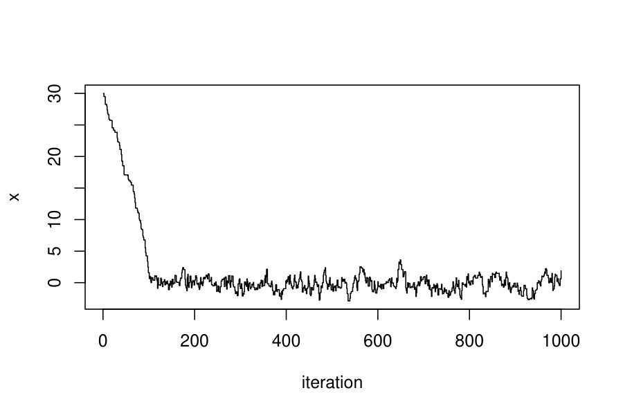

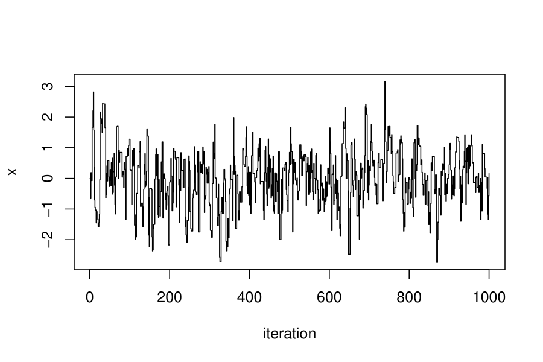

Choosing the proposal matrix

The proposal matrix influences the dependence between states: $x_t, x_{t+1}, x_{t+2}\ldots$ A bad choice can lead to bad mixing:

- Proposal variance too large: most proposals rejected and long runs of unchanging state
- Proposal variance too small: most moves small, and explore the posterior too slowly

We can detect bad mixing due to choice of $\Sigma$ using:

- Trace plots
- Acceptance rate (see later)
- Autocorrelation plots (see later)

We can use repeated runs to pick a good choice of $\Sigma$. Often we use $\lambda \hat{\Sigma}$ where $\hat{\Sigma}$ is an estimate of posterior variance.

It can also help to thin the chain, keeping only $x_k, x_{2k}, x_{3k}\ldots$. This reduces dependence. For example with $k=10$ (“lag 10”) we keep $x_{10}, x_{20}, x_{30}\ldots$

Trace plots and proposal matrix

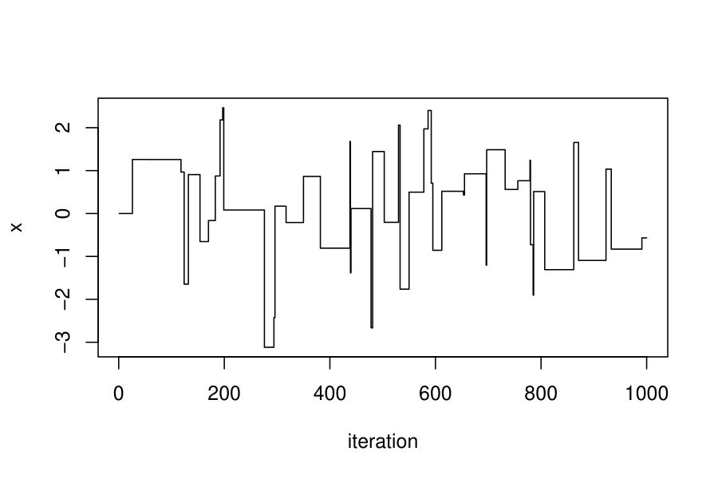

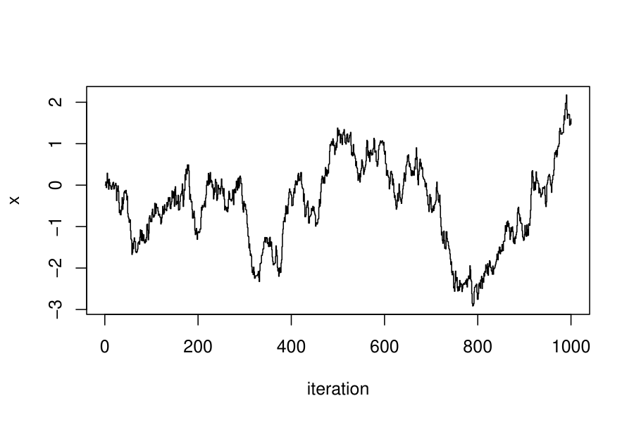

- Top: proposal variance too big – most proposals rejected
- Bottom: proposal variance too small – state moves too slowly

Acceptance rate diagnostic

The acceptance rate of Metropolis-Hastings output is the proportion of iterations where the proposal was accepted. This can be a useful diagnostic for choosing $\Sigma$:

- Low acceptance rate suggests most proposals rejected (proposal variance too big).
- High acceptance rate suggests most proposals were small (proposal variance too small).

We’d like the acceptance rate to be “just right” between these extremes. Theoretical work shows the optimal acceptance rate for random walk Metropolis-Hastings is 0.234. (This work uses very strong assumptions, but the result is surprisingly useful in practice.)

The acceptance rate is a useful diagnostic for Metropolis-Hastings, but is only a single number. It should be used with plots which give more insight into mixing behaviour.

Acceptance rate is not useful for all MCMC algorithms. For instance Gibbs samplers always have acceptance rate 1! These are discussed later and often used in JAGS.

Autocorrelation plots

Consider a univariate Markov chain (or other time series). The sample autocorrelation function (ACF) estimates $\mathrm{Corr}(X_{t}, X_{t+k})$: the correlation of states separated by $k$ time steps.

The formula used for time series $x_1, x_2, \ldots, x_T$ is:
$$\gamma(k)=\frac{\frac{1}{T-k}\sum_{t=k+1}^T\big(x_{t}-\bar{x}\big)\big(x_{t-k}-\bar{x}\big)}{\sqrt{\frac{1}{T}\sum_{t=1}^T\big(x_{t}-\bar{x}\big)^2\frac{1}{T-k}\sum_{t=k+1}^T\big(x_{t-k}-\bar{x}\big)^2}}$$
with $\bar{x}=\frac{1}{T}\sum_{t=1}^T x_{t}$.

(You don’t need to learn this formula for this course!)

An autocorrelation plot plots $k$ on the horizontal axis against $\gamma(k)$ on the vertical axis. Easy to produce on a computer (the `acf` command in R).

This can be used to:

- Diagnose problems with the choice of $\Sigma$.
- Pick a thinning interval $k$ such that $\gamma(k) \approx 0$.

More diagnostics

Another diagnostic is to run multiple chains. This is usually easy to do using parallel computing. You can then check that all chains end up with similar behaviour (e.g. using trace plots). This checks convergence.

Many other diagnostics have been proposed. See the textbook “Bayesian Data Analysis” for more details.

For example in JAGS you may see $\hat{R}$, which measures how similar multiple chains are to each other (values near 1 are good).

Diagnostics example 1

We return to some earlier example trace plots and show our three main diagnostics.

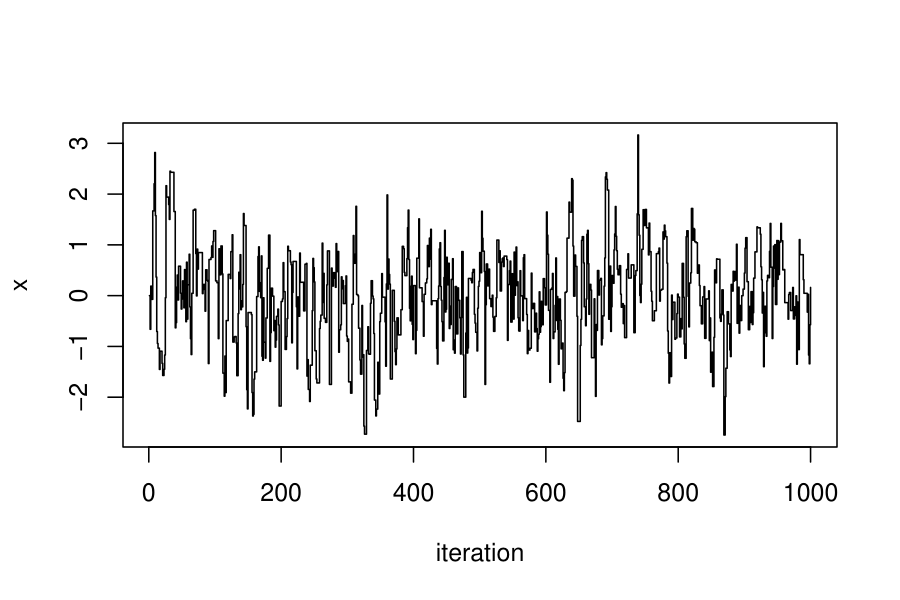

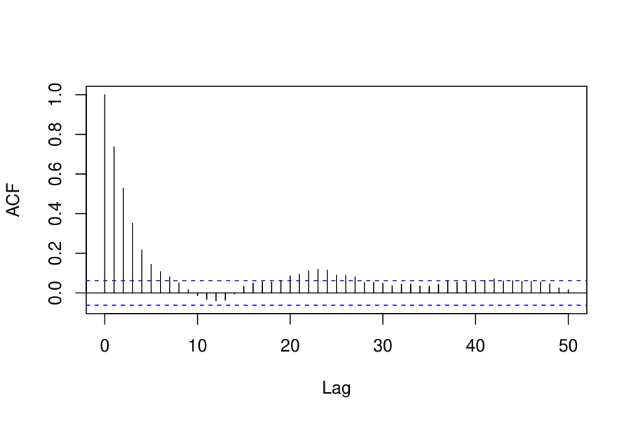

This has acceptance rate $0.69$. The traceplot shows reasonable mixing. But the acf plot shows there is some dependence up to about lag 10.

The acceptance rate is above the optimal value, suggesting we could try a larger proposal variance. Alternatively, just thinning with interval 10 should give reasonable MCMC estimates.

Diagnostics example 2

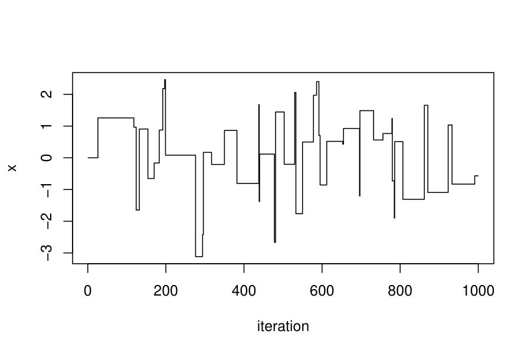

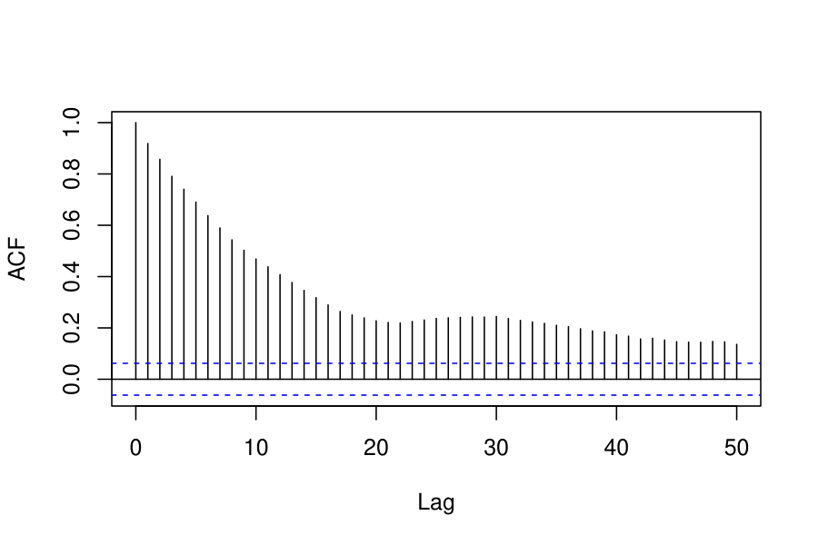

This has acceptance rate $0.05$.

Here the traceplot and low acceptance rate suggest the proposal variance is too high. This leads to long range dependence in the output, as shown by the acf.

The dependence seems too much to fix by thinning, and rerunning with better tuning is needed.

Diagnostics example 3

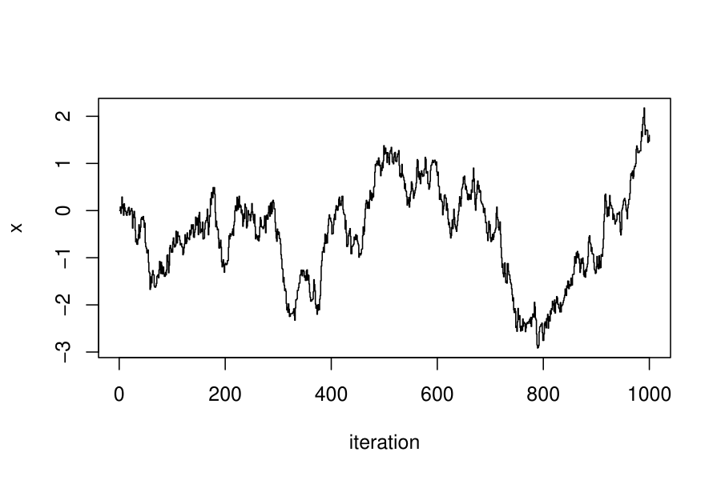

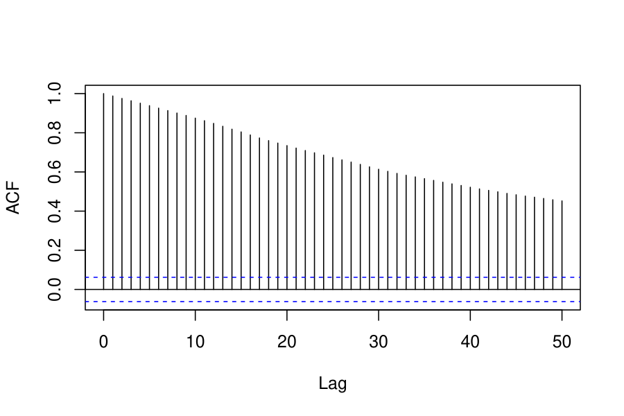

This has acceptance rate $0.96$.

Here the traceplot and high acceptance rate suggest the proposal variance is too low. This leads to long range dependence in the output, as shown by the acf.

The dependence is too much to fix by thinning, and rerunning with better tuning is needed.

4.7 The Gibbs sampler

The Gibbs sampler is another MCMC algorithm, which is useful when $S = \mathbb{R}^d$ for $d>1$.

First we need some definitions and notation.

Consider a density $\pi(x)$.

Denote the $i$th entry in the vector $x$ as $x^{(i)}$.

We define the full conditional density for $x^{(i)}$ under $\pi(x)$ as the conditional density for $x^{(i)}$ given all the other entries in $x$.

We write this as:
$$\pi(x^{(i)} | x^{(-i)}) = \pi(x^{(i)} | x^{(1)}, \ldots, x^{(i-1)}, x^{(i+1)}, \ldots, x^{(d)})$$
(with slight changes for $i=1$ and $i=d$.)

Full conditionals example

Suppose $X$ is uniform on the unit disc (the region inside the unit circle) centred at zero. Then:
$$\begin{aligned}
X^{(1)} | X^{(2)} &= a \sim \mathcal{U}( -\sqrt{1-a^2}, \sqrt{1-a^2} ) \\
X^{(2)} | X^{(1)} &= b \sim \mathcal{U}( -\sqrt{1-b^2}, \sqrt{1-b^2} ) \\
\end{aligned}$$

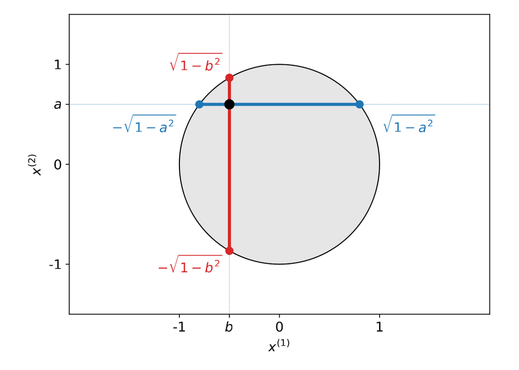

The Gibbs sampler

The Gibbs sampler is the following simple algorithm:

- Loop repeatedly over $i=1,2,\ldots,d$ and update $x^{(i)}$ from its full conditional.

This is the **fixed scan** Gibbs sampler, as the loop over $i=1,2,\ldots,d$ is in a fixed order.

Random scan Gibbs sampler

Gibbs sampler comments

#### Advantages

- The Gibbs sampler has no tuning choices (except the initial state).
- There is no accept/reject step.

#### Disadvantages

- You must be able to derive the full conditionals
- Can converge slowly when $\pi$ has strong dependence.

Example: suppose the target is uniform on a narrow diagonal ellipse. A Gibbs sampler explores this slowly as it can only take small steps.

Gibbs sampler validity (not examinable)

We’ll check that the random scan Gibbs sampler satisfies detailed balance. We need to show that for all $x,y \in \mathbb{R}^d$,
$$\pi(x) q(y | x) = \pi(y) q(x | y)$$
(4.1) where $q(x|y)$ is the probability density of moving to $x$ from $y$ in one Gibbs sampler iteration.

If $x$ and $y$ differ in more than one component, then $q(y|x) = q(x|y) = 0$, and (4.1) holds.

So let’s assume $x^{(-i)} = y^{(-i)}$ for some $i$. Then
$$q(y|x) = \frac{1}{d} \pi(y^{(i)} | x^{(-i)}), \quad
q(x|y) = \frac{1}{d} \pi(x^{(i)} | y^{(-i)}).$$

By conditional probability
$$\pi(x) = \pi(x^{(i)} | x^{(-i)}) \pi(x^{(-i)}), \quad
\pi(y) = \pi(y^{(i)} | y^{(-i)}) \pi(y^{(-i)}).$$

So the left hand side of (4.1) is
$$\pi(x^{(i)} | x^{(-i)}) \pi(x^{(-i)}) \frac{1}{d} \pi(y^{(i)} | x^{(-i)})$$
and the right hand side is
$$\pi(y^{(i)} | y^{(-i)}) \pi(y^{(-i)}) \frac{1}{d} \pi(x^{(i)} | y^{(-i)}).$$
These are equal because $x^{(-i)} = y^{(-i)}$.

#### Notation

Above, $\pi(x^{(-i)})$ is the joint density of all components of $x$ except $x^{(i)}$ i.e. $\pi(x^{(-i)}) = \int_{\mathbb{R}} \pi(x) dx^{(i)}$.

#### Fixed scan

We don’t cover the fixed scan proof, but it builds on the above.

Other MCMC algorithms and next steps

There are many other MCMC algorithms, including:

- Gibbs/Metropolis-Hastings hybrid algorithms (used in JAGS)
- Slice sampling (also used in JAGS)
- Hamiltonian Monte Carlo (used in Stan)

Developing new and more efficient MCMC algorithms remains a very active research area.

#### Next steps

We’ll look at performing MCMC in practice using JAGS: see the separate document.